# Predicting Shelter Outcomes

STAT5003 Assignment 2

W01G04

## 1. Problem Framing & Research Question

### Task and motivation

Animal shelters make care and placement decisions with limited space, staff and information. This study addresses a **five-class classification task**: predict Adoption, Transfer, Return, Euthanasia or Other from recorded characteristics of cats and dogs. The unit of analysis is each animal’s latest recorded intake in the supplied extract. Predictors are intended to describe information available at admission; their actual recording times are a limitation assessed below.

The motivation is to determine how much useful outcome information these characteristics contain and whether more flexible models improve on simple baselines. Overall accuracy alone is insufficient: a model that mostly recognises common outcomes can overlook animals in rarer outcome groups. We therefore compare macro-F1 and class-specific errors as well as accuracy.

### Research question

**To what extent can characteristics intended to be available at intake predict the five recorded shelter outcomes for each cat or dog’s latest admission, and which fitted model offers the best balance of class-level performance?**

### Stakeholders and intended use

**Intake Triage Officers** need evidence to support early assessment and prioritise cases for staff review. Recall for less common outcomes indicates how often relevant cases are detected; precision indicates how often a flag is a false alarm. These predictions could supplement professional judgement, but they do not measure medical deterioration, length of stay or the appropriate treatment for an animal.

**Transfer & Foster Coordinators** plan rescue-partner and foster placements under capacity constraints. Transfer predictions may help identify cases for placement review; a missed Transfer outcome and a false Transfer prediction have different practical costs. This study evaluates outcome classification, rather than forecasting placement dates or demonstrating reduced shelter stays.

A predicted historical outcome is not a recommendation about what should happen to an animal. The analysis tests associations in historical records, and operational use would first require verified intake-time inputs and an assessment of errors in the intended setting.

## 2. Dataset & Justification

### Source and analytical scope

We analysed the Austin Animal Center Outcomes extract from the City of Austin Open Data Portal (City of Austin, n.d.). The supplied file contains **17,246 records and 16 variables**. Selecting Dog, Puppy, Cat and Kitten yields **16,342 records** for EDA; retaining each animal’s latest recorded intake yields **15,680 animals** for modelling. This prevents the same animal appearing in training and assessment data.

### Evidence for the dataset criteria

- **Large:** the final sample contains 15,680 animals, exceeding 10,000 even after restricting the scope and removing repeated admissions.
- **Messy:** missing or blank names (37.9%), secondary colours (47.7%) and birth dates (4.4%), inconsistent categorical labels and invalid ages require explicit cleaning. Figure 1 shows the missingness evidence.
- **Multiclass:** five outcomes have substantially different frequencies. Figure 1 shows their distribution and why the evaluation must consider minority classes.

### Outcome definition

We consolidate 28 raw outcome labels into five operational groups. Adoption includes adoption variants; Transfer includes transfers out; Return includes reclaimed, redemption, return-to-owner and return-to-habitat records; Euthanasia includes euthanasia variants; Other contains the remaining death and administrative outcomes. Other is consequently a heterogeneous class.

## 3. EDA & Insights

### Data quality and outcome distribution

EDA examines the **16,342 selected records** using their original predictor values. Separate audit and plotting summaries describe missingness, inconsistencies and associations with `Outcome.Group`; selection of the final modelling sample and imputation begin in Data Preprocessing.

The audit finds **587 Animal IDs with repeated records**, but **0 exact duplicate rows**. Repeated Animal IDs may represent separate shelter episodes rather than duplicate records. There are 711 unavailable ages and a further 89 negative ages. These are separate data-quality findings. Negative ages remain in the audit; their conversion to missing values is a later preprocessing decision. No nonblank birth or intake dates failed parsing.

Adoption and Transfer account for 84.0% of selected records. A classifier can therefore achieve substantial accuracy while failing to recognise smaller outcome groups. Missingness is concentrated in secondary colour, name and birth date (Figure 1).

**Show R code**

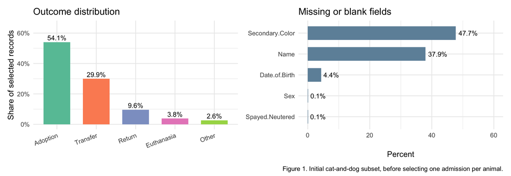

```r
p_class <- ggplot(group_summary, aes(Outcome.Group, Percentage, fill = Outcome.Group)) +
  geom_col(width = .68) + geom_text(aes(label = sprintf("%.1f%%", Percentage)), vjust = -.4, size = 3) +
  scale_fill_manual(values = palette_outcome, guide = "none") +
  scale_y_continuous(limits = c(0, 65), labels = function(x) paste0(x, "%")) +
  labs(title = "Outcome distribution", x = NULL, y = "Share of selected records") +
  theme(axis.text.x = element_text(angle = 20, hjust = 1))
miss <- quality_summary %>% filter(Feature %in% c("Secondary.Color", "Name", "Date.of.Birth", "Sex", "Spayed.Neutered"))
p_missing <- ggplot(miss, aes(reorder(Feature, Missing_pct), Missing_pct)) +
  geom_col(fill = "#6E91A8", width = .65) + coord_flip() +
  geom_text(aes(label = sprintf("%.1f%%", Missing_pct)), hjust = -.15, size = 3) +
  scale_y_continuous(limits = c(0, 60)) + labs(title = "Missing or blank fields", x = NULL, y = "Percent")
p_class + p_missing + patchwork::plot_annotation(caption = "Figure 1. Initial cat-and-dog subset, before selecting one admission per animal.")
```

**Show original EDA calculations and plotting source**

```r
eda <- local({
# Original EDA source retained from STAT5003_group_project_RMarkdown_template_v29.Rmd.
# Complete calculations are included here in an isolated scope for report layout.

# Original EDA chunk 1: eda-data-quality, message=FALSE, warning=FALSE
library(lubridate)

# EDA audit helpers: inspect blanks and read date strings without changing the source.
is_blank <- function(x) {
  is.na(x) | trimws(as.character(x)) == ""
}

parse_shelter_date <- function(x) {
  as.Date(parse_date_time(
    as.character(x),
    orders = c("Y b d I M S p", "ymd HMS", "mdy HMS", "dmy HMS",
               "ymd", "mdy", "dmy"),
    locale = "C", tz = "UTC", quiet = TRUE
  ))
}

# Keep this copy unchanged throughout EDA.
data_eda <- data_selected

# age check
age_audit <- tibble(
  DOB = parse_shelter_date(data_eda$Date.of.Birth),
  Intake_Date = parse_shelter_date(data_eda$Intake.Date)
) %>%
  mutate(Age_Years_raw = as.numeric(Intake_Date - DOB) / 365)

quality_features <- c(
  "Type", "Sex", "Spayed.Neutered", "Primary.Breed",
  "Primary.Color", "Secondary.Color", "Name", "Date.of.Birth", "Intake.Date"
)
quality_summary <- tibble(
  Feature = quality_features,
  Distinct_nonblank = sapply(quality_features, function(v) {
    x <- as.character(data_eda[[v]])
    n_distinct(x[!is_blank(x)])
  }),
  Missing_n = sapply(quality_features, function(v) sum(is_blank(data_eda[[v]]))),
  Missing_pct = 100 * Missing_n / nrow(data_eda),
  Unknown_label_n = sapply(quality_features, function(v) {
    sum(str_to_lower(trimws(as.character(data_eda[[v]]))) == "unknown",
        na.rm = TRUE)
  })
)
knitr::kable(quality_summary, digits = 2,
             caption = "Raw-field quality in the complete cat-and-dog subset")

quality_checks <- tibble(
  Check = c("Records", "Distinct nonmissing Animal IDs", "Exact duplicate rows",
            "Animal IDs with more than one record", "Missing Animal IDs",
            "Nonblank birth dates that failed parsing",
            "Nonblank intake dates that failed parsing",
            "Age unavailable from dates", "Negative ages observed"),
  Count = c(
    nrow(data_eda),
    n_distinct(data_eda$Animal.ID[!is_blank(data_eda$Animal.ID)]),
    sum(duplicated(data_eda)),
    sum(table(data_eda$Animal.ID[!is_blank(data_eda$Animal.ID)]) > 1),
    sum(is_blank(data_eda$Animal.ID)),
    sum(!is_blank(data_eda$Date.of.Birth) & is.na(age_audit$DOB)),
    sum(!is_blank(data_eda$Intake.Date) & is.na(age_audit$Intake_Date)),
    sum(is.na(age_audit$Age_Years_raw)),
    sum(age_audit$Age_Years_raw < 0, na.rm = TRUE)
  )
)
knitr::kable(quality_checks, caption = "Record and date checks")

# Original EDA chunk 2: eda-plot-helpers
# These functions aggregate observed categories
outcome_colours <- setNames(
  c("#66C2A5", "#FC8D62", "#8DA0CB", "#E78AC3", "#A6D854"),
  levels(data_eda$Outcome.Group)
)

outcome_summary <- function(df, feature) {
  df %>%
    mutate(Level = as.character(.data[[feature]])) %>%
    select(Level, Outcome.Group) %>%
    count(Level, Outcome.Group, .drop = FALSE) %>%
    group_by(Level) %>%
    mutate(Total = sum(n), Prop = n / Total) %>%
    ungroup()
}

# Axis labels distinguish NA, blanks and whitespace without changing their values.
display_eda_level <- function(x) {
  labels <- as.character(x)
  labels[is.na(x)] <- "<NA>"
  labels[!is.na(x) & x == ""] <- "<blank>"
  whitespace <- !is.na(x) & x != "" & trimws(x) == ""
  labels[whitespace] <- "<whitespace>"
  labels
}

plot_outcome_summary <- function(summary, title) {
  totals <- distinct(summary, Level, Total)
  ggplot(summary, aes(x = Level, y = Prop, fill = Outcome.Group)) +
    geom_col(width = 0.6) +
    scale_x_discrete(labels = function(x) {
      paste0(display_eda_level(x), "\n(n=",
             scales::comma(totals$Total[match(x, totals$Level)]), ")")
    }) +
    scale_y_continuous(labels = percent_format(),
                       expand = expansion(mult = c(0, 0.03))) +
    scale_fill_manual(values = outcome_colours, drop = FALSE) +
    labs(title = title, x = NULL, y = "Within-group proportion", fill = "Outcome") +
    theme_minimal(base_size = 9) +
    theme(plot.title = element_text(face = "bold", size = 10),
          axis.text.x = element_text(angle = 30, hjust = 1),
          panel.grid.minor = element_blank(), legend.position = "bottom")
}

plot_outcome <- function(df, feature, title) {
  plot_outcome_summary(outcome_summary(df, feature), title)
}

plot_outcome_heatmap <- function(summary, title) {
  totals <- distinct(summary, Level, Total)
  ggplot(summary, aes(x = Outcome.Group, y = Level, fill = Prop)) +
    geom_tile(colour = "white") +
    geom_text(aes(label = if_else(Prop >= 0.08, sprintf("%.0f%%", 100 * Prop), "")),
              size = 3) +
    scale_y_discrete(labels = function(x) {
      paste0(display_eda_level(x), " (n=",
             scales::comma(totals$Total[match(x, totals$Level)]), ")")
    }) +
    scale_fill_gradient(low = "#F0F4F8", high = "#1F78B4", labels = percent_format()) +
    labs(title = title, x = NULL, y = NULL, fill = "Proportion") +
    theme_minimal(base_size = 9) +
    theme(plot.title = element_text(face = "bold", size = 10),
          panel.grid = element_blank())
}

outcome_rate <- function(feature, level, outcome) {
  x <- outcome_summary(data_eda, feature)
  index <- !is.na(x$Level) & x$Level == level & x$Outcome.Group == outcome
  value <- x$Prop[index]
  if (length(value) == 0L) return("not observed")
  sprintf("%.1f%%", 100 * value)
}

# Original EDA chunk 3: type-outcome, fig.width=9, fig.height=3.5, out.width="85%", fig.align="center"
# Summarise original Type values
type_age_summary <- tibble(
  Type = data_eda$Type,
  Age_Years_raw = age_audit$Age_Years_raw
) %>%
  group_by(Type, .drop = TRUE) %>%
  summarise(
    n = n(),
    Missing_age = sum(is.na(Age_Years_raw)),
    Negative_age = sum(Age_Years_raw < 0, na.rm = TRUE),
    Median_age = median(Age_Years_raw[!is.na(Age_Years_raw) & Age_Years_raw >= 0]),
    Q1 = quantile(Age_Years_raw[!is.na(Age_Years_raw) & Age_Years_raw >= 0], 0.25),
    Q3 = quantile(Age_Years_raw[!is.na(Age_Years_raw) & Age_Years_raw >= 0], 0.75),
    .groups = "drop"
  )
knitr::kable(type_age_summary, digits = 2,
             caption = "Original Type categories and observed nonnegative age")
p_type_outcome <- plot_outcome(data_eda, "Type", "Shelter Outcome by Original Type")
print(p_type_outcome)
```

```r
# Original EDA chunk 4: , fig.width=9, fig.height=3.5, out.width="85%", fig.align='center'
library(ggplot2)
breed_summary <- data_selected %>%
  count(Primary.Breed, name = "Count") %>%
  arrange(desc(Count)) %>%
  mutate(
    Rank = row_number(),
    Pct = Count / sum(Count) * 100,
    Cum_Pct = cumsum(Pct)
  )

elbow_breed_rank <- 8
elbow_breed_val <- breed_summary$Cum_Pct[elbow_breed_rank]

# line plot for accumulated breed distribution
p_breed_elbow <- ggplot(breed_summary, aes(x = Rank, y = Cum_Pct)) +
  geom_area(fill = "#1f78b4", alpha = 0.12) +
  geom_line(color = "#1f78b4", linewidth = 1.2) +
  geom_hline(yintercept = 80, linetype = "dashed", color = "#666666", linewidth = 0.6) +
  geom_vline(xintercept = elbow_breed_rank, linetype = "dashed", color = "#666666", linewidth = 0.6) +
  geom_point(data = filter(breed_summary, Rank == elbow_breed_rank),
             color = "#e31a1c", size = 3.5) +
  geom_point(data = filter(breed_summary, Rank == elbow_breed_rank),
             color = "white", size = 1.5) +
  scale_x_continuous(
    breaks = c(1, 8, 25, 50, 100, 150, 193),
    expand = expansion(mult = c(0.01, 0.03))
  ) +
  scale_y_continuous(
    limits = c(0, 103),
    breaks = seq(0, 100, by = 20),
    labels = function(x) paste0(x, "%"),
    expand = expansion(mult = c(0, 0.01))
  ) +
  labs(
    title = "Primary Breed Cumulative Coverage",
    x = "Breed Rank (Ordered by Population Frequency)",
    y = "Cumulative Share of Population"
  ) +
  theme_minimal(base_size = 12) +
  theme(
    plot.title = element_text(face = "bold", size = 13, color = "#1a1a1a"),
    plot.subtitle = element_text(color = "#555555", margin = margin(b = 10)),
    panel.grid.minor = element_blank(),
    panel.grid.major = element_line(color = "#ebebeb"),
    axis.line = element_line(color = "#cccccc"),
    axis.title = element_text(face = "bold", size = 10.5)
  )

print(p_breed_elbow)

# Original EDA chunk 5: , fig.width=9, fig.height=3.5, out.width="85%", fig.align='center'
# library(tidyverse)
#
# #
# raw_colors <- colour_eda$Primary.Color[!is.na(colour_eda$Primary.Color) & trimws(colour_eda$Primary.Color) != ""]
#
#
# tokens <- unlist(strsplit(tolower(raw_colors), "[^a-zA-Z]+"))
# tokens <- tokens[tokens != ""]
#
# word_freq <- as.data.frame(table(word = tokens), stringsAsFactors = FALSE) %>%
#   rename(n = Freq) %>%
#   arrange(desc(n)) %>%
#   mutate(pct = round(n / sum(n) * 100, 2))
# write.csv(word_freq, 'word_freq.csv')
# Group base_color type and Check if pattern
# Use a plotting copy; keep the original selected records unchanged.
colour_eda <- data_eda %>%
  mutate(
    Base_Color = case_when(
      str_detect(str_to_lower(Primary.Color), regex("brown|tan|choc|fawn|buff|sable|liver|cinnamon|rust|agouti|bronze|chestnut|sandy|seal", ignore_case = TRUE)) ~ "Brown/Tan",
      str_detect(str_to_lower(Primary.Color), regex("black|charcoal|sooty", ignore_case = TRUE)) ~ "Black",
      str_detect(str_to_lower(Primary.Color), regex("white|cream|blonde|albino|champagne|wheat|snow", ignore_case = TRUE)) ~ "White/Cream",
      str_detect(str_to_lower(Primary.Color), regex("blue|grey|gray|silver|lilac|wolf", ignore_case = TRUE)) ~ "Blue/Grey",
      str_detect(str_to_lower(Primary.Color), regex("orange|red|ginger|yellow|gold|apricot|lemon|flame", ignore_case = TRUE)) ~ "Orange/Red",
      TRUE ~ "Other"
    ),
    Base_Color = as.factor(Base_Color),
    has_pattern = if_else(
      (!is.na(Secondary.Color) & Secondary.Color != '') |
      str_detect(str_to_lower(Primary.Color), regex("tabby|brindle|smoke|Point|calico|torbie|tort|tri|merle|tiger|ticked|lynx|roan|bicolor|patch|shaded", ignore_case = TRUE)),
      "Mixed",
      "Pure"
    ),
    has_pattern = as.factor(has_pattern)
  )


# Base_Color distribution
p_base_bar <- ggplot(colour_eda, aes(x = Base_Color, fill = Base_Color)) +
  geom_bar(width = 0.6, show.legend = FALSE) +
  geom_text(
    stat = "count",
    aes(label = sprintf("%.1f%%\n(%s)",
                        after_stat(count) / sum(after_stat(count)) * 100,
                        format(after_stat(count), big.mark = ","))),
    vjust = -0.05,
    size = 3.2
  ) +
  scale_y_continuous(expand = expansion(mult = c(0, 0.30))) +
  scale_fill_brewer(palette = "Set2") +
  labs(
    title = "Distribution of Base Colors",
    x = "Base Color Group",
    y = "Count"
  ) +
  theme_minimal(base_size = 12) +
  theme(
    plot.title = element_text(face = "bold", size = 8),
    axis.text.x = element_text(angle = 35, hjust = 1, size = 7),
    panel.grid.minor = element_blank()
  )



# has_pattern distribution
p_pattern_bar <- ggplot(colour_eda, aes(x = has_pattern, fill = has_pattern)) +
  geom_bar(width = 0.5, show.legend = FALSE) +
  geom_text(
    stat = "count",
    aes(label = sprintf("%.1f%%\n(%s)",
                        after_stat(count) / sum(after_stat(count)) * 100,
                        format(after_stat(count), big.mark = ","))),
    vjust = -0.05,
    size = 3.2
  ) +
  scale_y_continuous(expand = expansion(mult = c(0, 0.30))) +
  scale_fill_manual(values = c("Pure" = "#4575b4", "Mixed" = "#fdae61")) +
  labs(
    title = "Distribution of Patterns",
    x = "Pattern",
    y = "Count"
  ) +
  theme_minimal(base_size = 12) +
  theme(
    plot.title = element_text(face = "bold", size = 8),
    panel.grid.minor = element_blank()
  )

base_outcome_pct <- colour_eda %>%
  count(Base_Color, Outcome.Group) %>%
  group_by(Base_Color) %>%
  mutate(
    Prop = n / sum(n),
    label_text = if_else(
      Outcome.Group %in% c("Adoption", "Transfer"),
      sprintf("%.1f%%", Prop * 100),
      ""
    )
  ) %>%
  ungroup()

p_base_vs_outcome <- ggplot(base_outcome_pct, aes(x = Base_Color, y = Prop, fill = Outcome.Group)) +
  geom_col(position = "fill", width = 0.6) +
  geom_text(
    aes(label = label_text),
    position = position_fill(vjust = 0.5),
    color = "white",
    fontface = "bold",
    size = 3.2
  ) +
  scale_y_continuous(labels = percent_format(), expand = expansion(mult = c(0, 0.05))) +
  scale_fill_brewer(palette = "Set2") +
  labs(
    title = "Base Color Groups Across Outcome",
    x = "Base Color Group",
    y = "Proportion (%)",
    fill = "Outcome Group"
  ) +
  theme_minimal(base_size = 12) +
  theme(
    plot.title = element_text(face = "bold", size = 8),
    axis.text.x = element_text(angle = 35, hjust = 1, size = 7),
    legend.position = "right",
    legend.title = element_text(size = 8),
    legend.text = element_text(size = 7),
    legend.key.height = grid::unit(0.35, "cm")
  )
```

```r
p_base_bar + p_pattern_bar + p_base_vs_outcome+ plot_layout(widths = c(1.5, 1, 1))

# Original EDA chunk 6: pattern-outcome-additional, fig.width=9, fig.height=3.5, out.width="85%", fig.align="center"
p_pattern_outcome <- plot_outcome(
  colour_eda, "has_pattern", "Shelter Outcome by Pattern"
)
print(p_pattern_outcome)

# Original EDA chunk 7: , fig.width=9, fig.height=3.5, out.width="85%", fig.align='center'
library(lubridate)

# Calculate observed ages in a plotting copy only.
age_eda <- data_eda %>%
  # Use calendar dates, consistent with the audit and model features.
  mutate(
    DOB = parse_shelter_date(Date.of.Birth),
    Intake_Date = parse_shelter_date(Intake.Date),
    Age_Years = as.numeric(Intake_Date - DOB) / 365
  )

# Display observed nonnegative ages; do not replace or impute values in EDA.
# Missing and negative ages remain documented in the earlier data-quality audit.
age_eda <- age_eda %>%
  filter(!is.na(Age_Years), Age_Years >= 0)

# plot for age vs type, to check how to deal with missing value
p_age_by_type <- ggplot(age_eda, aes(x = Type, y = Age_Years, fill = Type)) +
  geom_boxplot(
    width = 0.5,
    alpha = 0.8,
    outlier.size = 1.2,
    outlier.alpha = 0.3,
    outlier.color = "grey40",
    show.legend = FALSE
  ) +
  scale_y_continuous(breaks = seq(0, 25, by = 2)) +
  scale_fill_brewer(palette = "Set2") +
  labs(
    title = "Age Distribution Across Animal Types",
    x = "Animal Type",
    y = "Age (Years)"
  ) +
  theme_minimal(base_size = 8) +
  theme(
    plot.title = element_text(face = "bold"),
    panel.grid.minor = element_blank()
  )

p_age_dist <- ggplot(filter(age_eda, !is.na(Age_Years), Age_Years >= 0), aes(x = Age_Years)) +
  geom_histogram(binwidth = 1, fill = "#1f78b4", color = "white", boundary = 0) +
  scale_x_continuous(breaks = seq(0, 25, by = 2)) +
  labs(
    title = "Distribution of Age at Intake",
    x = "Age (Years)",
    y = "Count"
  ) +
  theme_minimal(base_size = 8) +
  theme(plot.title = element_text(face = "bold"), panel.grid.minor = element_blank())



p_age_outcome <- ggplot(filter(age_eda, !is.na(Age_Years), Age_Years >= 0),
                        aes(x = Outcome.Group, y = Age_Years, fill = Outcome.Group)) +
  geom_boxplot(outlier.colour = "red", outlier.shape = 1, outlier.alpha = 0.4, width = 0.55, show.legend = FALSE) +
  scale_y_continuous(breaks = seq(0, 25, by = 2)) +
  scale_fill_brewer(palette = "Set2") +
  labs(
    title = "Age by Outcome",
    x = "Outcome Group",
    y = "Age (Years)"
  ) +
  theme_minimal(base_size = 8) +
  theme(
    plot.title = element_text(face = "bold"),
    panel.grid.minor = element_blank()
  )

p_age_dist + p_age_by_type + p_age_outcome + plot_layout(widths = c(0.8, 0.8, 1))

# Original EDA chunk 8: , fig.width=9, fig.height=3.5, out.width="85%", fig.align='center'
p_sex_dist <- ggplot(data_selected, aes(x = Sex, fill = Sex)) +
  geom_bar(width = 0.5, show.legend = FALSE) +
  geom_text(
    stat = "count",
    aes(label = sprintf("%.1f%%\n(%s)",
                        after_stat(count) / sum(after_stat(count)) * 100,
                        format(after_stat(count), big.mark = ","))),
    vjust = -0.05, size = 3.2
  ) +
  scale_y_continuous(expand = expansion(mult = c(0, 0.30))) +
  scale_fill_brewer(palette = "Set2") +
  labs(
    title = "Distribution of Sex",
    x = "Sex",
    y = "Count") +
  theme_minimal(base_size = 12) +
  theme(
    plot.title = element_text(face = "bold", margin = margin(b = 8)),
    panel.grid.minor = element_blank()
  )

p_neuter_dist <- ggplot(data_selected, aes(x = Spayed.Neutered, fill = Spayed.Neutered)) +
  geom_bar(width = 0.5, show.legend = FALSE) +
  geom_text(
    stat = "count",
    aes(label = sprintf("%.1f%%\n(%s)",
                        after_stat(count) / sum(after_stat(count)) * 100,
                        format(after_stat(count), big.mark = ","))),
    vjust = -0.05, size = 3.2
  ) +
  scale_y_continuous(expand = expansion(mult = c(0, 0.30))) +
  scale_fill_brewer(palette = "Pastel1") +
  labs(title = "Distribution of Spayed/Neutered Status",
       x = "Spayed.Neutered",
       y = "Count") +
  theme_minimal(base_size = 12) +
  theme(
    plot.title = element_text(face = "bold", margin = margin(b = 8)),
    panel.grid.minor = element_blank()
  )

p_sex_dist + p_neuter_dist + plot_layout(widths = c(1, 1))

p_sex_outcome <- ggplot(
  data_selected %>% filter(!is.na(Sex), !is.na(Outcome.Group)),
  aes(x = Sex, fill = Outcome.Group)
) +
  geom_bar(position = "fill", width = 0.6) +
  scale_y_continuous(
    labels = scales::percent_format(),
    expand = expansion(mult = c(0, 0.02))
  ) +
  scale_fill_brewer(palette = "Set2") +
  labs(
    title = "Shelter Outcome by Sex",
    x = "Sex",
    y = "Proportion",
    fill = "Outcome"
  ) +
  theme_minimal(base_size = 12) +
  theme(
    plot.title = element_text(face = "bold", margin = margin(b = 8)),
    panel.grid.minor = element_blank(),
    legend.position = "bottom"
  )


p_neuter_outcome <- ggplot(
  data_selected %>% filter(!is.na(Spayed.Neutered), !is.na(Outcome.Group)),
  aes(x = Spayed.Neutered, fill = Outcome.Group)
) +
  geom_bar(position = "fill", width = 0.6) +
  scale_y_continuous(
    labels = scales::percent_format(),
    expand = expansion(mult = c(0, 0.02))
  ) +
  scale_fill_brewer(palette = "Set2") +
  labs(
    title = "Shelter Outcome by Spayed/Neutered Status",
    x = "Spayed/Neutered",
    y = "Proportion",
    fill = "Outcome"
  ) +
  theme_minimal(base_size = 12) +
  theme(
    plot.title = element_text(face = "bold", margin = margin(b = 8)),
    panel.grid.minor = element_blank(),
    legend.position = "bottom"
  )


p_sex_outcome + p_neuter_outcome +
  plot_layout(widths = c(1, 1), guides = "collect") &
  theme(legend.position = "bottom")

# Original EDA chunk 9: name-outcome, fig.width=9, fig.height=3.5, out.width="85%", fig.align="center"
# Whitespace/case checks identify placeholders for the audit
name_outcome_pct <- data_eda %>%
  group_by(Outcome.Group, .drop = FALSE) %>%
  summarise(
    Recorded = sum(
      !is_blank(Name) &
        !(str_to_lower(trimws(as.character(Name))) %in%
            c("unknown", "*", "n/a", "na"))
    ),
    Placeholder = sum(
      !is_blank(Name) &
        str_to_lower(trimws(as.character(Name))) %in%
          c("unknown", "*", "n/a", "na")
    ),
    Blank = sum(
      !is.na(Name) & trimws(as.character(Name)) == "",
      na.rm = TRUE
    ),
    Missing = sum(is.na(Name)),
    .groups = "drop"
  ) %>%
  pivot_longer(-Outcome.Group, names_to = "Level", values_to = "n") %>%
  group_by(Level) %>%
  mutate(
    Total = sum(n),
    Prop = if_else(Total > 0, n / Total, 0)
  ) %>%
  ungroup() %>%
  filter(Total > 0)
```

```r
p_name_outcome <- plot_outcome_summary(
  name_outcome_pct, "Shelter Outcome by Observed Name Recording"
)
print(p_name_outcome)
  environment()
})
```

### Type, age and overlapping information

Puppy and Kitten already describe life stage as well as species, so their relationship with observed age indicates overlapping information. The age summaries use only nonnegative observed ages, with missing and negative counts reported separately. Median ages are 1.50 years for Dog and 0.42 for Cat, compared with 0.13 for Puppy and 0.09 for Kitten.

The distribution is severely right-skewed. Animals that were Adopted or Transferred skew noticeably younger, whereas those in the Return or Euthanasia groups skew older. The Return proportions are 16.5% for Dog, 1.2% for Puppy, 6.8% for Cat and 0.1% for Kitten. Alongside the age summaries, these differences motivate representing species and continuous age separately in the modelling dataset.

**Show R code**

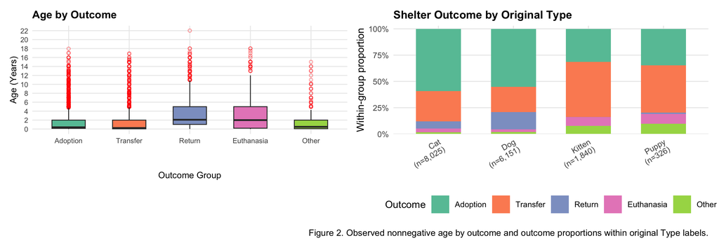

```r
# Retain the original EDA plots and categories; adjust layout only.
eda$p_age_outcome + eda$p_type_outcome +
  patchwork::plot_annotation(caption = "Figure 2. Observed nonnegative age by outcome and outcome proportions within original Type labels.")
```

### Breed, colour and coat pattern

There are 193 distinct breed labels recorded; the top eight cover 80.3% of selected records, while 44 labels occur only once. To limit sparse categories, Data Preprocessing retains the eight most common non-Unknown breeds identified in each training partition and groups all remaining or unseen breeds as Other.

The original colour analysis uses a separate plotting copy: primary colours are grouped into base colours, and a non-empty secondary colour or patterned-coat keyword identifies Mixed rather than Pure. White/Cream animals show the highest Return proportion of any colour group, while Blue/Grey animals show a comparatively higher Euthanasia proportion. The additional pattern comparison shows Adoption proportions of 56.1% for Mixed and 46.4% for Pure. These are associations between recorded categories and outcomes.

**Show R code**

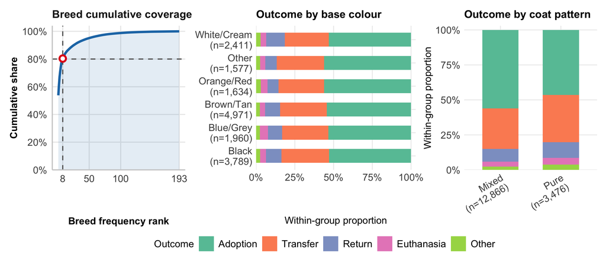

Figure 3. Original breed distribution and colour/pattern outcome proportions; sample sizes are shown with category labels.

```r
# Original summaries and plotting functions; one shared legend saves space.
p_breed <- eda$p_breed_elbow +
  scale_x_continuous(breaks = c(8, 50, 100, nrow(eda$breed_summary))) +
  labs(title = "Breed cumulative coverage", x = "Breed frequency rank", y = "Cumulative share")
p_colour <- eda$plot_outcome(eda$colour_eda, "Base_Color", "Outcome by base colour") +
  coord_flip() + theme(axis.text.x = element_text(angle = 0, hjust = .5),
                       axis.text.y = element_text(angle = 0, hjust = 1))
p_pattern <- eda$p_pattern_outcome + labs(title = "Outcome by coat pattern")
(p_breed + p_colour + p_pattern +
   patchwork::plot_layout(widths = c(1, 1.2, 1), guides = "collect")) &
  theme(legend.position = "bottom", plot.title = element_text(size = 11.5),
        axis.title = element_text(size = 10.5), axis.text = element_text(size = 10.5),
        legend.title = element_text(size = 10.5), legend.text = element_text(size = 10.5),
        legend.margin = margin(0, 0, 0, 0))
```

### Sex, spay/neuter status and name recording

Sex and Spayed/Neutered contain blank values, and Spayed/Neutered additionally has inconsistent capitalisation (Yes and yes both appear and represent the same value). Both issues are corrected in Data Preprocessing; the plots below use the raw values to document what the inconsistency actually looks like before cleaning. Adoption proportions differ even between Yes (79.7%) and yes (98.9%), so these patterns require attention to recording practices.

EDA compares outcome proportions across observed name-recording conditions: non-placeholder text, placeholder text, blank text and NA. This is a missingness audit of Name, not construction of the binary has_Name predictor. Original names are retained; the binary modelling variable is created only in Data Preprocessing. The present subset has no NA names; the observed groups are shown with their sample sizes. Adoption accounts for 71.5% of the Recorded group and 27.2% of the Blank group.

**Show R code**

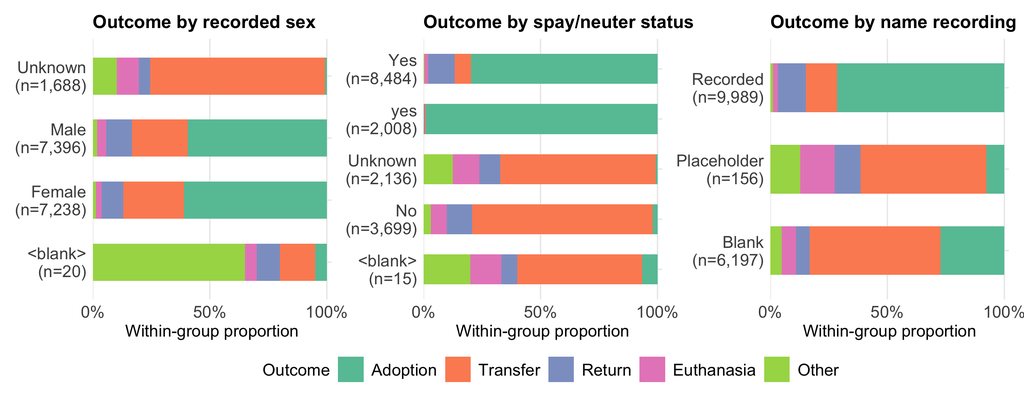

Figure 4. Raw sex/neuter labels and name-recording groups, with group sizes; no imputation or label standardisation in EDA.

```r
p_sex <- eda$plot_outcome(eda$data_eda, "Sex", "Outcome by recorded sex")
p_neuter <- eda$plot_outcome(eda$data_eda, "Spayed.Neutered", "Outcome by spay/neuter status")
p_name <- eda$p_name_outcome + labs(title = "Outcome by name recording")
# Horizontal bars leave room for larger, unrotated category and sample-size labels.
readable_outcomes <- function(p) {
  p + coord_flip() +
    scale_y_continuous(breaks = c(0, .5, 1), labels = scales::percent,
                       expand = expansion(mult = c(0, .02))) +
    theme(axis.text.x = element_text(angle = 0, hjust = .5),
          axis.text.y = element_text(angle = 0, hjust = 1))
}
(readable_outcomes(p_sex) + readable_outcomes(p_neuter) + readable_outcomes(p_name) +
   patchwork::plot_layout(guides = "collect")) &
  theme(legend.position = "bottom", plot.title = element_text(size = 11.5),
        axis.title = element_text(size = 10.5), axis.text = element_text(size = 10.5),
        legend.title = element_text(size = 10.5), legend.text = element_text(size = 10.5),
        legend.margin = margin(0, 0, 0, 0))
```

Differences between these recording groups may reflect administrative practices or prior ownership information. This comparison cannot establish those explanations or confirm that names were available at intake. Type already contains age-related labels; breed and colour have many categories; date differences include missing and negative values; and Sex, Spayed/Neutered and Name contain recording issues. These findings motivate the explicit preprocessing choices in the next section. The class imbalance supports macro-F1 and per-class recall, while predictive value is assessed using shared cross-validation splits. EDA uses the full selected subset and is not independent performance evidence.

## 4. Data Preprocessing

We retain the latest intake timestamp for each animal, resolving ties by source row order. This removes 662 additional records without using the outcome to choose an admission. A stratified 80/20 split with seed 5003 gives **12,546 training animals and 3,134 test animals**. Five outcome-stratified folds within training are shared by all models. Animal IDs are used only for grouping and checks.

| Predictor | Implemented treatment |
| --- | --- |
| Species | Recode Puppy to Dog and Kitten to Cat. |
| Age at intake | Calendar-day difference between intake and birth, divided by 365; negative values become missing. Impute from the training median within species, with an overall training-median fallback. |
| Sex; spayed/neutered | Trim and standardise labels; represent missing or unrecognised values as Unknown. |
| Primary breed | Retain the eight most frequent non-Unknown breeds in the training partition; group the rest and unseen breeds as Other. |
| Base colour; pattern | Apply fixed text rules to colour fields; pattern indicates a recorded secondary colour or patterned-coat keyword. |
| Name recorded | Binary indicator; blank, missing and placeholder names are coded absent. |

Outcome date/status, euthanasia reason, completed days in shelter, identifiers and administrative timestamps are excluded from predictors. Raw names, dates and text are replaced by their derived features. Imputation and breed grouping are re-estimated within each training fold, then applied to validation rows. Model-specific encoding and age transformations also use the corresponding training rows. Name, neutering status and the colour indicators remain recording-based proxies whose availability at admission requires verification.

**Show R code**

```r
shared <- local({
suppressPackageStartupMessages({
library(dplyr); library(tidyr); library(stringr); library(forcats);
library(ggplot2); library(scales); library(lubridate);
library(caret); library(ranger); library(knitr)
})
set.seed(5003)
# ---- dataset-scope ----
knitr::opts_chunk$set(
  message = FALSE,
  warning = FALSE
)

library(tidyr)
library(dplyr)
library(stringr)
library(forcats)
library(ggplot2)
library(scales)
library(patchwork)

# The CSV is stored in the same folder as this R Markdown file.
data <- read.csv(
  params$data_file,
  stringsAsFactors = TRUE
)

# Restrict the scope to cats and dogs and consolidate the 28 raw outcomes.
data_selected <- data %>%
  filter(Type %in% c("Dog", "Puppy", "Cat", "Kitten")) %>%
  mutate(
    Outcome.Group = case_when(
      str_detect(Outcome.Status, regex("Adopt", ignore_case = TRUE)) ~ "Adoption",
      str_detect(Outcome.Status, regex("Transfer", ignore_case = TRUE)) ~ "Transfer",
      str_detect(Outcome.Status, regex("Euthan", ignore_case = TRUE)) ~ "Euthanasia",
      str_detect(
        Outcome.Status,
        regex("Reclaim|Redemption|Returned To Owner|Return to Habitat", ignore_case = TRUE)
      ) ~ "Return",
      TRUE ~ "Other"
    ),
    Outcome.Group = factor(
      Outcome.Group,
      levels = c("Adoption", "Transfer", "Return", "Euthanasia", "Other")
    )
  )

group_summary <- data_selected %>%
  count(Outcome.Group, name = "Count") %>%
  mutate(
    Percentage = 100 * Count / sum(Count),
    Outcome.Group = factor(Outcome.Group, levels = levels(data_selected$Outcome.Group))
  )

key_missing <- c(
  "Name", "Euthanasia.Reason", "Secondary.Color",
  "Date.of.Birth", "Spayed.Neutered"
)

missing_summary <- tibble(
  Feature = key_missing,
  Missing_Pct = sapply(
    key_missing,
    function(feature) {
      values <- data_selected[[feature]]
      100 * mean(is.na(values) | trimws(as.character(values)) == "")
    }
  )
) %>%
  arrange(Missing_Pct) %>%
  mutate(Feature = factor(Feature, levels = Feature))



# ---- eda-data-quality ----
library(lubridate)

# EDA audit helpers: inspect blanks and read date strings without changing the source.
is_blank <- function(x) {
  is.na(x) | trimws(as.character(x)) == ""
}

parse_shelter_date <- function(x) {
  as.Date(parse_date_time(
    as.character(x),
    orders = c("Y b d I M S p", "ymd HMS", "mdy HMS", "dmy HMS",
               "ymd", "mdy", "dmy"),
    locale = "C", tz = "UTC", quiet = TRUE
  ))
}

# Keep this copy unchanged throughout EDA.
data_eda <- data_selected

# age check
age_audit <- tibble(
  DOB = parse_shelter_date(data_eda$Date.of.Birth),
  Intake_Date = parse_shelter_date(data_eda$Intake.Date)
) %>%
  mutate(Age_Years_raw = as.numeric(Intake_Date - DOB) / 365)

quality_features <- c(
  "Type", "Sex", "Spayed.Neutered", "Primary.Breed",
  "Primary.Color", "Secondary.Color", "Name", "Date.of.Birth", "Intake.Date"
)
quality_summary <- tibble(
  Feature = quality_features,
  Distinct_nonblank = sapply(quality_features, function(v) {
    x <- as.character(data_eda[[v]])
    n_distinct(x[!is_blank(x)])
  }),
  Missing_n = sapply(quality_features, function(v) sum(is_blank(data_eda[[v]]))),
  Missing_pct = 100 * Missing_n / nrow(data_eda),
  Unknown_label_n = sapply(quality_features, function(v) {
    sum(str_to_lower(trimws(as.character(data_eda[[v]]))) == "unknown",
        na.rm = TRUE)
  })
)


quality_checks <- tibble(
  Check = c("Records", "Distinct nonmissing Animal IDs", "Exact duplicate rows",
            "Animal IDs with more than one record", "Missing Animal IDs",
            "Nonblank birth dates that failed parsing",
            "Nonblank intake dates that failed parsing",
            "Age unavailable from dates", "Negative ages observed"),
  Count = c(
    nrow(data_eda),
    n_distinct(data_eda$Animal.ID[!is_blank(data_eda$Animal.ID)]),
    sum(duplicated(data_eda)),
    sum(table(data_eda$Animal.ID[!is_blank(data_eda$Animal.ID)]) > 1),
    sum(is_blank(data_eda$Animal.ID)),
    sum(!is_blank(data_eda$Date.of.Birth) & is.na(age_audit$DOB)),
    sum(!is_blank(data_eda$Intake.Date) & is.na(age_audit$Intake_Date)),
    sum(is.na(age_audit$Age_Years_raw)),
    sum(age_audit$Age_Years_raw < 0, na.rm = TRUE)
  )
)



# ---- latest-intake-record ----
# Preprocessing 1. Retain one record per animal: its latest recorded intake.
# Keep the source row order so tied intake timestamps have a fixed rule.
data_latest <- data_selected %>%
  mutate(
    .source_row = row_number(),
    Intake_Datetime = parse_date_time(
      as.character(Intake.Date),
      orders = c("Y b d I M S p", "ymd HMS", "mdy HMS", "dmy HMS",
                 "ymd", "mdy", "dmy"),
      locale = "C", tz = "UTC", quiet = TRUE
    )
  )

data_latest <- data_latest %>%
  # Sort each animal's records from newest to oldest.
  # For equal timestamps, the first row in the source file comes first.
  arrange(Animal.ID, desc(Intake_Datetime), .source_row) %>%
  group_by(Animal.ID) %>%
  filter(row_number() == 1) %>%
  ungroup() %>%
  # Restore source order and remove the temporary selection columns.
  arrange(.source_row) %>%
  select(-.source_row, -Intake_Datetime)


# ---- fixed-model-features ----
# Preprocessing 2-6. Construct model features from the retained latest-intake records.
prepare_features <- function(df) {
  df %>%
    mutate(
      # 2. Type-Age redundancy: Type now contains species only.
      Type_original = as.character(Type),
      Type = factor(case_when(
        Type_original %in% c("Dog", "Puppy") ~ "Dog",
        Type_original %in% c("Cat", "Kitten") ~ "Cat",
        TRUE ~ NA_character_
      ), levels = c("Cat", "Dog")),

      # 3. Age at intake: this is the first conversion of negative ages to NA.
      DOB = parse_shelter_date(Date.of.Birth),
      Intake_Date = parse_shelter_date(Intake.Date),
      Age_Years_raw = as.numeric(Intake_Date - DOB) / 365,
      Age_Years = if_else(Age_Years_raw < 0, NA_real_, Age_Years_raw),

      # 4. Name: treat blanks and case-insensitive placeholders as not recorded.
      has_Name = factor(if_else(
        is_blank(Name) | str_to_lower(trimws(as.character(Name))) %in%
          c("unknown", "*", "n/a", "na"), "0", "1"
      ), levels = c("0", "1")),
```

```r
      # 5. Sex / Spayed.Neutered: standardise spelling, case and missing values.
      Sex = factor(case_when(
        str_to_lower(trimws(as.character(Sex))) == "male" ~ "Male",
        str_to_lower(trimws(as.character(Sex))) == "female" ~ "Female",
        TRUE ~ "Unknown"
      ), levels = c("Female", "Male", "Unknown")),
      Spayed.Neutered = factor(case_when(
        str_to_lower(trimws(as.character(Spayed.Neutered))) == "yes" ~ "Yes",
        str_to_lower(trimws(as.character(Spayed.Neutered))) == "no" ~ "No",
        TRUE ~ "Unknown"
      ), levels = c("No", "Yes", "Unknown")),

      # 6. Breed / Colour: fixed text cleaning; frequency grouping is deferred.
      Primary.Breed = if_else(is_blank(Primary.Breed), "Unknown",
                              trimws(as.character(Primary.Breed))),
      Base_Color = factor(case_when(
        is_blank(Primary.Color) ~ "Unknown",
        str_detect(Primary.Color, regex("brown|tan|choc|fawn|buff|sable|liver|cinnamon|rust|agouti|bronze|chestnut|sandy|seal", ignore_case = TRUE)) ~ "Brown/Tan",
        str_detect(Primary.Color, regex("black|charcoal|sooty", ignore_case = TRUE)) ~ "Black",
        str_detect(Primary.Color, regex("white|cream|blonde|albino|champagne|wheat|snow", ignore_case = TRUE)) ~ "White/Cream",
        str_detect(Primary.Color, regex("blue|grey|gray|silver|lilac|wolf", ignore_case = TRUE)) ~ "Blue/Grey",
        str_detect(Primary.Color, regex("orange|red|ginger|yellow|gold|apricot|lemon|flame", ignore_case = TRUE)) ~ "Orange/Red",
        TRUE ~ "Other"
      )),
      has_pattern = factor(case_when(
        !is_blank(Secondary.Color) |
          coalesce(str_detect(Primary.Color, regex(
            "tabby|brindle|smoke|point|calico|torbie|tort|tri|merle|tiger|ticked|lynx|roan|bicolor|patch|shaded",
            ignore_case = TRUE
          )), FALSE) ~ "Mixed",
        is_blank(Primary.Color) ~ "Unknown",
        TRUE ~ "Pure"
      ), levels = c("Pure", "Mixed", "Unknown"))
    )
}

data_features <- prepare_features(data_latest)

# ---- shared-data-split ----
# Preprocessing 7. Shared 80/20 split and 5 CV folds using caret.
library(caret)
set.seed(5003)

# createDataPartition returns the training row numbers, stratified by outcome.
train_index <- createDataPartition(
  data_features$Outcome.Group,
  p = 0.8,
  list = FALSE
)
train_raw <- data_features[train_index, ]
test_raw <- data_features[-train_index, ]
y_train <- train_raw$Outcome.Group
y_test <- test_raw$Outcome.Group

# Each list element contains the validation row numbers within train_raw.
cv_folds <- createFolds(
  y_train,
  k = 5,
  list = TRUE,
  returnTrain = FALSE
)

# ---- common-train-test-preprocessing ----
# 8. Learn species-specific age medians from training only.
overall_age_median <- median(train_raw$Age_Years, na.rm = TRUE)
age_medians <- train_raw %>%
  group_by(Type) %>%
  summarise(Age_Median = median(Age_Years, na.rm = TRUE), .groups = "drop")

# 9. Select the eight most common recorded breeds in training.
top8_breeds <- train_raw %>%
  filter(Primary.Breed != "Unknown") %>%
  count(Primary.Breed, name = "Count") %>%
  arrange(desc(Count), Primary.Breed) %>%
  filter(row_number() <= 8) %>%
  pull(Primary.Breed)

# 10. Keep these eight predictors in x_train/x_test; y_train/y_test hold the outcome.
model_predictors <- c(
  "Type", "Sex", "Spayed.Neutered", "primary.breed.group",
  "Base_Color", "has_pattern", "has_Name", "Age_Years_imputed"
)
factor_predictors <- setdiff(model_predictors, "Age_Years_imputed")

# Apply steps 8-10 to training: fill missing ages and group breeds.
# Use the overall training median only if a species median is unavailable.
x_train <- train_raw %>%
  left_join(age_medians, by = "Type") %>%
  mutate(
    Age_Years_imputed = case_when(
      !is.na(Age_Years) ~ Age_Years,
      !is.na(Age_Median) ~ Age_Median,
      TRUE ~ overall_age_median
    ),
    primary.breed.group = if_else(
      Primary.Breed %in% top8_breeds, Primary.Breed, "Other"
    )
  ) %>%
  select(all_of(model_predictors))

# Apply the same training medians and breed list to the test data.
x_test <- test_raw %>%
  left_join(age_medians, by = "Type") %>%
  mutate(
    Age_Years_imputed = case_when(
      !is.na(Age_Years) ~ Age_Years,
      !is.na(Age_Median) ~ Age_Median,
      TRUE ~ overall_age_median
    ),
    primary.breed.group = if_else(
      Primary.Breed %in% top8_breeds, Primary.Breed, "Other"
    )
  ) %>%
  select(all_of(model_predictors))

# Use the same factor levels in training and test data.
for (variable in factor_predictors) {
  x_train[[variable]] <- factor(x_train[[variable]])
  x_test[[variable]] <- factor(
    x_test[[variable]],
    levels = levels(x_train[[variable]])
  )
}


# ---- common-cv-preprocessing ----
# Repeat steps 8-10 within each fold, starting from data before imputation.
# Learn the rules from fold_train only, then apply them to fold_valid.
cv_data <- list()
for (k in 1:5) {
  fold_train <- train_raw[-cv_folds[[k]], ]
  fold_valid <- train_raw[cv_folds[[k]], ]

  # 8. Age medians from this fold's training data.
  fold_overall_median <- median(fold_train$Age_Years, na.rm = TRUE)
  fold_age_medians <- fold_train %>%
    group_by(Type) %>%
    summarise(Age_Median = median(Age_Years, na.rm = TRUE), .groups = "drop")

  # 9. Top eight breeds from this fold's training data.
  fold_top8_breeds <- fold_train %>%
    filter(Primary.Breed != "Unknown") %>%
    count(Primary.Breed, name = "Count") %>%
    arrange(desc(Count), Primary.Breed) %>%
    filter(row_number() <= 8) %>%
    pull(Primary.Breed)

  # 8-10. Apply the rules and keep the common predictors.
  fold_train <- fold_train %>%
    left_join(fold_age_medians, by = "Type") %>%
    mutate(
      Age_Years_imputed = case_when(
        !is.na(Age_Years) ~ Age_Years,
        !is.na(Age_Median) ~ Age_Median,
        TRUE ~ fold_overall_median
      ),
      primary.breed.group = if_else(
        Primary.Breed %in% fold_top8_breeds, Primary.Breed, "Other"
      )
    ) %>%
    select(Outcome.Group, all_of(model_predictors))
```

```r
  fold_valid <- fold_valid %>%
    left_join(fold_age_medians, by = "Type") %>%
    mutate(
      Age_Years_imputed = case_when(
        !is.na(Age_Years) ~ Age_Years,
        !is.na(Age_Median) ~ Age_Median,
        TRUE ~ fold_overall_median
      ),
      primary.breed.group = if_else(
        Primary.Breed %in% fold_top8_breeds, Primary.Breed, "Other"
      )
    ) %>%
    select(Outcome.Group, all_of(model_predictors))

  # 10. Use this fold's training factor levels for validation.
  for (variable in factor_predictors) {
    fold_train[[variable]] <- factor(fold_train[[variable]])
    fold_valid[[variable]] <- factor(
      fold_valid[[variable]],
      levels = levels(fold_train[[variable]])
    )
  }

  cv_data[[k]] <- list(
    x_train = select(fold_train, all_of(model_predictors)),
    y_train = fold_train$Outcome.Group,
    x_valid = select(fold_valid, all_of(model_predictors)),
    y_valid = fold_valid$Outcome.Group
  )
}

# Each cv_data[[k]] contains x_train, y_train, x_valid and y_valid.
# Validation data stay separate from the final x_test/y_test holdout.
# cv_folds[[k]] identifies the validation rows for out-of-fold predictions.
# This block prepares common data; model fitting/scoring belongs in each model section.

# Variable  Description
# x_train   Preprocessed predictors for the full training set (80%).
# y_train   Outcome labels for the full training set.
# x_test    Test predictors processed using the training-derived rules (20%).
# y_test    Outcome labels for final test evaluation.
# 5-fold CV : cv_data
  rng_state <- .Random.seed
  environment()
})
# Expose shared summaries to the narrative and plots.
list2env(as.list(shared, all.names = TRUE), envir = environment())
```

## 5. Model Fitting

### Common fitting procedure

Five fitted classifiers use the same eight core predictors and shared five-fold partitions. For each fold, preprocessing is learned from its training rows, the model is fitted to those rows, and predictions are recorded for the validation rows. Combining these predictions gives one out-of-fold prediction per training animal. Hyperparameters and feature changes are evaluated in Section 6; model comparison is reported in Section 7. Each folded model panel below contains its complete fitting, tuning, prediction and result-calculation code. All preprocessing, model grids, predictions, checks and report tables are executed within this document. Knitting recomputes the results from the raw CSV; it does not read previously saved model outputs. Decision tree is included alongside logistic regression, random forest, SVM and XGBoost.

### Majority class (baseline)

The common reference baseline predicts the most frequent training class for every animal, without using predictors. It is **Adoption** in each training fold. The majority class accounts for 53.21% of the full training partition, while the smallest class, Other, accounts for 2.65%.

On the training labels, this rule achieves accuracy 0.532 and weighted-F1 0.370, but macro-F1 only 0.139 and balanced accuracy 0.200. This illustrates why prevalence-weighted scores can look substantial even when four outcomes are never predicted. The comparison table evaluates this baseline on validation folds, selecting the majority from each fold’s training labels. It is a reference rule, separate from the five fitted model families and their own initial configurations.

### Multinomial logistic regression

The initial M0 model is fitted with `nnet::multinom`, using treatment-coded categories and training-standardised age. It estimates class probabilities through linear predictors for the class log-odds and assigns the class with the largest probability. This provides a relatively interpretable baseline for assessing whether nonlinear models add predictive value. Regularisation, class weights and nonlinear age features are evaluated in Section 6; the resulting M3 model is fitted with `glmnet`.

**Show logistic regression fitting and baseline CV code**

```r
# Complete multinomial logistic-regression workflow, evaluated in an isolated scope.
# All inputs come from the shared preprocessing already executed in this Rmd.
# Model results stay in memory; no external R scripts or saved result files are used.
lr_results <- local({
  suppressPackageStartupMessages({
    library(dplyr)
    library(tidyr)
    library(ggplot2)
    library(nnet)
    library(glmnet)
    library(splines)
  })
  x_train <- shared$x_train
  x_test <- shared$x_test
  y_train <- shared$y_train
  y_test <- shared$y_test
  train_raw <- shared$train_raw
  test_raw <- shared$test_raw
  cv_folds <- shared$cv_folds
  cv_data <- shared$cv_data
  data_features <- shared$data_features
  model_predictors <- shared$model_predictors
  factor_predictors <- shared$factor_predictors
  classes <- levels(y_train)
  stopifnot(!anyNA(x_train), !anyNA(x_test))
  set.seed(5003)

  # ---- design-helpers ----
  # Metrics used by the whole group: macro-F1 (primary), balanced accuracy, per-class recall.
  class_metrics <- function(truth, pred) {
    truth <- factor(truth, levels = classes); pred <- factor(pred, levels = classes)
    cm <- table(Truth = truth, Pred = pred)
    recall <- diag(cm) / rowSums(cm)
    precision <- ifelse(colSums(cm) > 0, diag(cm) / colSums(cm), 0)
    f1 <- ifelse(precision + recall > 0, 2 * precision * recall / (precision + recall), 0)
    list(cm = cm, recall = recall, precision = precision, f1 = f1,
         summary = c(macro_F1 = mean(f1), balanced_accuracy = mean(recall),
                     accuracy = sum(diag(cm)) / sum(cm)))
  }

  class_weights <- function(y) {
    w <- length(y) / (length(levels(y)) * as.numeric(table(y)))
    setNames(w, levels(y))[as.character(y)]
  }

  ref_levels <- function(x) {
    fixed <- c(Type = "Cat", Sex = "Female", has_pattern = "Pure", has_Name = "0")
    sapply(names(Filter(is.factor, x)), function(v) {
      if (v %in% names(fixed)) fixed[[v]] else names(which.max(table(x[[v]])))
    })
  }

  # Build train/new design matrices with rules learned from the training part only.
  # spec = "base": shared 8 predictors, linear standardised age.
  # spec = "extended": + ns(log1p(age), 3) + Dog x log-age + age_missing flag.
  build_design <- function(xtr, xnew, miss_tr, miss_new, spec = "base", drop = character(0)) {
    refs <- ref_levels(xtr)
    prep <- function(x) {
      for (v in names(refs)) x[[v]] <- relevel(factor(x[[v]], levels = levels(xtr[[v]])), refs[[v]])
      x[, setdiff(names(x), c("Age_Years_imputed", drop)), drop = FALSE]
    }
    ftr <- prep(xtr); fnew <- prep(xnew)
    mm <- function(f) model.matrix(~ ., data = f)[, -1, drop = FALSE]
    Xtr <- mm(ftr); Xnew <- mm(fnew)
    mu <- mean(xtr$Age_Years_imputed); s <- sd(xtr$Age_Years_imputed)
    if (spec == "base") {
      Xtr <- cbind(Xtr, age_z = (xtr$Age_Years_imputed - mu) / s)
      Xnew <- cbind(Xnew, age_z = (xnew$Age_Years_imputed - mu) / s)
    } else {
      la_tr <- log1p(xtr$Age_Years_imputed); la_new <- log1p(xnew$Age_Years_imputed)
      basis <- ns(la_tr, df = 3)
      B_tr <- basis; B_new <- predict(basis, la_new)
      colnames(B_tr) <- colnames(B_new) <- paste0("age_ns", 1:3)
      lm_ <- mean(la_tr); ls_ <- sd(la_tr)
      Xtr <- cbind(Xtr, unclass(B_tr)[, 1:3],
                   dog_x_logage = (xtr$Type == "Dog") * (la_tr - lm_) / ls_,
                   age_missing = as.numeric(miss_tr))
      Xnew <- cbind(Xnew, B_new,
                    dog_x_logage = (xnew$Type == "Dog") * (la_new - lm_) / ls_,
                    age_missing = as.numeric(miss_new))
    }
    colnames(Xtr) <- colnames(Xnew) <- make.names(colnames(Xtr))
    # Drop any column that is constant in training (zero variance).
    keep <- apply(Xtr, 2, function(z) length(unique(z)) > 1)
    list(Xtr = Xtr[, keep, drop = FALSE], Xnew = Xnew[, keep, drop = FALSE])
  }

  # Age missing flag (missing DOB or negative age), aligned to shared rows.
  miss_train <- is.na(train_raw$Age_Years)
  miss_test <- is.na(test_raw$Age_Years)
  fold_miss <- lapply(seq_along(cv_folds), function(k) list(
    tr = miss_train[-cv_folds[[k]]], va = miss_train[cv_folds[[k]]]))
  for (k in seq_along(cv_data)) {          # check alignment with the shared cv_data
    stopifnot(identical(cv_data[[k]]$y_valid, y_train[cv_folds[[k]]]))
  }

  # ---- collinearity ----
  X_base <- build_design(x_train, x_train, miss_train, miss_train, "base")$Xtr
  vif <- sapply(colnames(X_base), function(j) {
    r2 <- summary(lm(X_base[, j] ~ X_base[, -which(colnames(X_base) == j)]))$r.squared
    1 / (1 - r2)
  })
  vif_tab <- tibble(Column = names(vif), VIF = unname(vif)) %>% arrange(desc(VIF))

  fac <- names(Filter(is.factor, x_train))
  cramer <- outer(fac, fac, Vectorize(function(a, b) {
    t <- table(x_train[[a]], x_train[[b]])
    s <- suppressWarnings(chisq.test(t, correct = FALSE)$statistic)
    sqrt(unname(s) / (sum(t) * (min(dim(t)) - 1)))
  }))
  dimnames(cramer) <- list(fac, fac)

  # ---- cv-models ----
  alphas <- c(0, 0.25, 0.5, 0.75, 1)
  n_lambda <- 40

  fit_multinom <- function(X, y, w = NULL) {
    df <- data.frame(X, .y = y)
    if (is.null(w)) w <- rep(1, length(y))
    multinom(.y ~ ., data = df, weights = w, maxit = 1000, MaxNWts = 10000, trace = FALSE)
  }
  pred_multinom <- function(fit, X) as.character(predict(fit, newdata = data.frame(X), type = "class"))

  fold_rows <- list()
  multinom_predictions <- list(
    "M0 multinom" = vector("list", length(cv_data)),
    "M1 multinom + weights" = vector("list", length(cv_data))
  )

  # Majority-class reference and plain multinomial models
  for (k in seq_along(cv_data)) {
    d <- cv_data[[k]]
    yva <- d$y_valid
    maj <- names(which.max(table(d$y_train)))
    m <- class_metrics(yva, rep(maj, length(yva)))
    fold_rows[[length(fold_rows) + 1]] <- tibble(Model = "Majority class", Fold = k, !!!as.list(m$summary),
                                                 !!!setNames(as.list(m$recall), paste0("recall_", classes)))
    des <- build_design(d$x_train, d$x_valid, fold_miss[[k]]$tr, fold_miss[[k]]$va, "base")
    for (mod in c("M0 multinom", "M1 multinom + weights")) {
      w <- if (mod == "M0 multinom") NULL else class_weights(d$y_train)
      fit <- fit_multinom(des$Xtr, d$y_train, w)
      pred <- pred_multinom(fit, des$Xnew)
      multinom_predictions[[mod]][[k]] <- pred
      m <- class_metrics(yva, pred)
      fold_rows[[length(fold_rows) + 1]] <- tibble(Model = mod, Fold = k, !!!as.list(m$summary),
                                                   !!!setNames(as.list(m$recall), paste0("recall_", classes)))
    }
  }
```

```r
  # glmnet: shared lambda path per alpha from the full training data, then fold scores
  tune_glmnet <- function(spec) {
    full <- build_design(x_train, x_train, miss_train, miss_train, spec)
    res <- list()
    predictions <- list()
    for (a in alphas) {
      path <- glmnet(full$Xtr, y_train, family = "multinomial", type.multinomial = "grouped",
                     alpha = a, weights = class_weights(y_train), nlambda = n_lambda,
                     lambda.min.ratio = 1e-4)$lambda
      fold_predictions <- vector("list", length(cv_data))
      for (k in seq_along(cv_data)) {
        d <- cv_data[[k]]
        des <- build_design(d$x_train, d$x_valid, fold_miss[[k]]$tr, fold_miss[[k]]$va, spec)
        fit <- glmnet(des$Xtr, d$y_train, family = "multinomial", type.multinomial = "grouped",
                      alpha = a, weights = class_weights(d$y_train), lambda = path)
        pr <- predict(fit, des$Xnew, type = "class")
        fold_predictions[[k]] <- pr
        for (j in seq_along(path)) {
          m <- class_metrics(d$y_valid, pr[, j])
          res[[length(res) + 1]] <- tibble(spec = spec, alpha = a, lambda = path[j], Fold = k,
                                           !!!as.list(m$summary),
                                           !!!setNames(as.list(m$recall), paste0("recall_", classes)))
        }
      }
      predictions[[as.character(a)]] <- list(lambda = path, folds = fold_predictions)
    }
    list(scores = bind_rows(res), predictions = predictions)
  }
  tuned <- list(base = tune_glmnet("base"), extended = tune_glmnet("extended"))
  grid <- bind_rows(tuned$base$scores, tuned$extended$scores)

  grid_summary <- grid %>% group_by(spec, alpha, lambda) %>%
    summarise(mean_macro_F1 = mean(macro_F1), se_macro_F1 = sd(macro_F1) / sqrt(n()),
              mean_bal_acc = mean(balanced_accuracy), .groups = "drop")

  pick_1se <- function(s) {
    best <- s[which.max(s$mean_macro_F1), ]
    cand <- s %>% filter(alpha == best$alpha, mean_macro_F1 >= best$mean_macro_F1 - best$se_macro_F1)
    list(best = best, one_se = cand[which.max(cand$lambda), ])
  }
  sel <- lapply(c(base = "base", extended = "extended"),
                function(sp) pick_1se(filter(grid_summary, spec == sp)))

  for (sp in names(sel)) {
    ch <- sel[[sp]]$one_se
    rows <- grid %>% filter(spec == sp, alpha == ch$alpha, lambda == ch$lambda) %>%
      mutate(Model = if (sp == "base") "M2 glmnet + weights" else "M3 glmnet + weights + age features") %>%
      select(Model, Fold, macro_F1, balanced_accuracy, accuracy, starts_with("recall_"))
    fold_rows[[length(fold_rows) + 1]] <- rows
  }
  fold_metrics <- bind_rows(fold_rows)

  cv_summary <- fold_metrics %>% group_by(Model) %>%
    summarise(macro_F1_sd = sd(macro_F1),
              across(c(macro_F1, balanced_accuracy, accuracy, starts_with("recall_")), mean),
              .groups = "drop") %>%
    relocate(macro_F1_sd, .after = macro_F1) %>% arrange(desc(macro_F1))

  tuned_tab <- bind_rows(lapply(names(sel), function(sp) bind_rows(
    mutate(sel[[sp]]$best, rule = "best (lambda.min)"),
    mutate(sel[[sp]]$one_se, rule = "1-SE (used)"))))

  # ---- tuning-plot ----
  p_tune <- ggplot(grid_summary, aes(x = log10(lambda), y = mean_macro_F1, colour = factor(alpha))) +
    geom_line() + facet_wrap(~ spec) +
    geom_vline(data = bind_rows(lapply(names(sel), function(sp) sel[[sp]]$one_se)),
               aes(xintercept = log10(lambda)), linetype = "dashed") +
    labs(x = expression(log[10](lambda)), y = "CV macro-F1", colour = expression(alpha),
         title = "Elastic-net tuning on the shared folds (dashed = 1-SE choice)") +
    theme_minimal(base_size = 9)

  # ---- choose-final ----
  lr_models <- cv_summary %>% filter(Model != "Majority class")
  final_name <- lr_models$Model[1]
  final_spec <- if (grepl("age features", final_name)) "extended" else "base"
  final_is_glmnet <- grepl("glmnet", final_name)
  final_weighted <- grepl("weights", final_name)
  final_alpha <- if (final_is_glmnet) sel[[final_spec]]$one_se$alpha else NA
  final_lambda <- if (final_is_glmnet) sel[[final_spec]]$one_se$lambda else NA

  # ---- final-fit ----
  fit_final <- function(xtr, ytr, xnew, mtr, mnew, drop = character(0)) {
    des <- build_design(xtr, xnew, mtr, mnew, final_spec, drop)
    w <- if (final_weighted) class_weights(ytr) else NULL
    if (final_is_glmnet) {
      fit <- glmnet(des$Xtr, ytr, family = "multinomial", type.multinomial = "grouped",
                    alpha = final_alpha, weights = w, lambda = final_lambda)
      prob <- predict(fit, des$Xnew, type = "response")[, , 1]
    } else {
      fit <- fit_multinom(des$Xtr, ytr, w)
      prob <- predict(fit, newdata = data.frame(des$Xnew), type = "probs")
    }
    list(fit = fit, prob = prob, pred = classes[max.col(prob, ties.method = "first")],
         cols = colnames(des$Xtr))
  }
  final <- fit_final(x_train, y_train, x_test, miss_train, miss_test)
  test_m <- class_metrics(y_test, final$pred)

  cv_final <- cv_summary %>% filter(Model == final_name)
  metrics_out <- bind_rows(
    tibble(Model = final_name, Evaluation = "5-fold CV (mean)", macro_F1 = cv_final$macro_F1,
           balanced_accuracy = cv_final$balanced_accuracy, accuracy = cv_final$accuracy,
           !!!as.list(unlist(cv_final[paste0("recall_", classes)]))),
    tibble(Model = final_name, Evaluation = "Held-out test (20%)", !!!as.list(test_m$summary),
           !!!setNames(as.list(test_m$recall), paste0("recall_", classes))))

  per_class <- tibble(Class = classes, n_test = as.numeric(table(y_test)),
                      Precision = test_m$precision, Recall = test_m$recall, F1 = test_m$f1)

  # ---- confusion-matrix ----
  cm_df <- as.data.frame(test_m$cm) %>% group_by(Truth) %>%
    mutate(Row_pct = Freq / sum(Freq)) %>% ungroup()
  p_cm <- ggplot(cm_df, aes(x = Pred, y = forcats::fct_rev(Truth), fill = Row_pct)) +
    geom_tile(colour = "white") +
    geom_text(aes(label = sprintf("%d\n(%.0f%%)", Freq, 100 * Row_pct)), size = 3) +
    scale_fill_gradient(low = "#F0F4F8", high = "#1F78B4", labels = scales::percent) +
    labs(x = "Predicted", y = "Actual", fill = "Row %",
         title = "Logistic regression – held-out test confusion matrix") +
    theme_minimal(base_size = 10) + theme(panel.grid = element_blank())
```

```r
  # ---- oof-predictions ----
  # Reuse the exact class predictions scored during CV. Refitting a single
  # lambda can differ from its path fit, and another class call can break ties differently.
  selected_predictions <- if (final_is_glmnet) {
    candidate <- tuned[[final_spec]]$predictions[[as.character(final_alpha)]]
    lambda_index <- match(final_lambda, candidate$lambda)
    stopifnot(length(lambda_index) == 1L, !is.na(lambda_index))
    lapply(candidate$folds, function(pr) as.character(pr[, lambda_index]))
  } else {
    multinom_predictions[[final_name]]
  }
  oof_df <- bind_rows(lapply(seq_along(cv_data), function(k) {
    d <- cv_data[[k]]
    pred <- selected_predictions[[k]]
    stopifnot(length(pred) == length(d$y_valid), !anyNA(pred))
    data.frame(train_row = cv_folds[[k]], Animal.ID = train_raw$Animal.ID[cv_folds[[k]]],
               Fold = k, truth = d$y_valid, pred = pred, check.names = FALSE)
  })) %>% arrange(train_row)

  # ---- odds-ratios ----
  des_or <- build_design(x_train, x_test, miss_train, miss_test, "base")
  X_or <- des_or$Xtr
  X_or[, "age_z"] <- x_train$Age_Years_imputed          # odds ratio per year of age
  colnames(X_or)[colnames(X_or) == "age_z"] <- "Age_years"
  fit_or <- fit_multinom(X_or, y_train)
  co <- coef(fit_or); se <- summary(fit_or)$standard.errors
  or_tab <- expand.grid(Outcome = rownames(co), Term = colnames(co), stringsAsFactors = FALSE) %>%
    mutate(coef = co[cbind(Outcome, Term)], se = se[cbind(Outcome, Term)],
           OR = exp(coef), OR_low = exp(coef - 1.96 * se), OR_high = exp(coef + 1.96 * se),
           p_value = 2 * pnorm(-abs(coef / se))) %>%
    filter(Term != "(Intercept)") %>% arrange(Outcome, Term)

  # Likelihood-ratio test for dropping each predictor (overall contribution)
  drop_lr <- bind_rows(lapply(setdiff(names(x_train), character(0)), function(v) {
    cols <- if (v == "Age_Years_imputed") "Age_years" else grep(paste0("^", make.names(v)), colnames(X_or), value = TRUE)
    f0 <- fit_multinom(X_or[, setdiff(colnames(X_or), cols), drop = FALSE], y_train)
    lr <- deviance(f0) - deviance(fit_or); dfree <- length(cols) * (length(classes) - 1)
    tibble(Predictor = v, LR_chisq = lr, df = dfree, p_value = pchisq(lr, dfree, lower.tail = FALSE))
  })) %>% arrange(desc(LR_chisq))

  if (final_is_glmnet) {
    cf <- coef(final$fit)
    final_coef <- bind_rows(lapply(names(cf), function(cl) tibble(
      Outcome = cl, Term = rownames(cf[[cl]]), coef = as.numeric(cf[[cl]]))))
  } else {
    cf <- coef(final$fit)
    final_coef <- as.data.frame(as.table(cf)) %>% rename(Outcome = Var1, Term = Var2, coef = Freq)
  }
  if (final_is_glmnet) {
    zero_terms <- final_coef %>% filter(Term != "(Intercept)") %>% group_by(Term) %>%
      summarise(all_zero = all(coef == 0)) %>% filter(all_zero) %>% pull(Term)
  }

  # ---- or-plot ----
  p_or <- or_tab %>%
    mutate(Term = gsub("^primary\\.breed\\.group", "Breed: ", Term),
           Term = gsub("^Base_Color", "Colour: ", Term),
           Term = gsub("^Spayed\\.Neutered", "Spayed/Neutered: ", Term),
           Term = gsub("^has_pattern", "Pattern: ", Term)) %>%
    ggplot(aes(x = OR, y = Term)) +
    geom_vline(xintercept = 1, linetype = "dashed", colour = "grey50") +
    geom_errorbarh(aes(xmin = OR_low, xmax = OR_high), height = 0.2, colour = "grey40") +
    geom_point(size = 1.4, colour = "#1F78B4") +
    scale_x_log10() + facet_wrap(~ Outcome, nrow = 1) +
    labs(x = "Odds ratio vs Adoption (log scale, 95% CI)", y = NULL,
         title = "Multinomial LR odds ratios (reference outcome = Adoption)") +
    theme_minimal(base_size = 8)

  # ---- or-highlights ----
  key_terms <- c("TypeDog", "Age_years", "has_Name1", "Spayed.NeuteredNo", "Spayed.NeuteredUnknown",
                 "SexUnknown", "has_patternMixed")
  or_of <- function(term, out) sprintf("%.2f", or_tab$OR[or_tab$Term == term & or_tab$Outcome == out])

  # ---- sensitivity ----
  sens <- list()
  for (dr in list(c("Spayed.Neutered"), c("Spayed.Neutered", "has_Name"))) {
    sc <- sapply(seq_along(cv_data), function(k) {
      d <- cv_data[[k]]
      r <- fit_final(d$x_train, d$y_train, d$x_valid, fold_miss[[k]]$tr, fold_miss[[k]]$va, drop = dr)
      class_metrics(d$y_valid, r$pred)$summary
    })
    sens[[length(sens) + 1]] <- tibble(Check = paste("CV without", paste(dr, collapse = " + ")),
                                       !!!as.list(rowMeans(sc)))
  }

  # Temporal hold-out: reapply the shared training-only rules (steps 8-10).
  apply_shared_rules <- function(tr, new) {
    med_all <- median(tr$Age_Years, na.rm = TRUE)
    meds <- tr %>% group_by(Type) %>% summarise(Age_Median = median(Age_Years, na.rm = TRUE), .groups = "drop")
    top8 <- tr %>% filter(Primary.Breed != "Unknown") %>% count(Primary.Breed, name = "Count") %>%
      arrange(desc(Count), Primary.Breed) %>% filter(row_number() <= 8) %>% pull(Primary.Breed)
    f <- function(df) df %>% left_join(meds, by = "Type") %>%
      mutate(Age_Years_imputed = case_when(!is.na(Age_Years) ~ Age_Years, !is.na(Age_Median) ~ Age_Median,
                                           TRUE ~ med_all),
             primary.breed.group = if_else(Primary.Breed %in% top8, Primary.Breed, "Other")) %>%
      select(all_of(model_predictors))
    a <- f(tr); b <- f(new)
    for (v in factor_predictors) { a[[v]] <- factor(a[[v]]); b[[v]] <- factor(b[[v]], levels = levels(a[[v]])) }
    list(x_tr = a, x_new = b)
  }
  outcome_dt <- as.Date(lubridate::parse_date_time(as.character(data_features$Outcome.Date),
                        orders = c("mdy IMS p", "mdy HMS", "ymd HMS"), locale = "C", tz = "UTC", quiet = TRUE))
  stopifnot(!anyNA(outcome_dt))
  cut_date <- as.Date("2026-07-01")
  tr_t <- data_features[outcome_dt < cut_date, ]; te_t <- data_features[outcome_dt >= cut_date, ]
  sr <- apply_shared_rules(tr_t, te_t)
  ok <- complete.cases(sr$x_new)
  r_t <- fit_final(sr$x_tr, tr_t$Outcome.Group, sr$x_new[ok, ], is.na(tr_t$Age_Years), is.na(te_t$Age_Years)[ok])
  m_t <- class_metrics(te_t$Outcome.Group[ok], r_t$pred)
  sens[[length(sens) + 1]] <- tibble(Check = sprintf("Temporal hold-out (train n=%d, test n=%d, outcome >= %s)",
                                                     nrow(tr_t), sum(ok), cut_date), !!!as.list(m_t$summary))
  sens_tab <- bind_rows(tibble(Check = "Reference: chosen model, held-out test", !!!as.list(test_m$summary)),
                        tibble(Check = "Reference: chosen model, CV", macro_F1 = cv_final$macro_F1,
                               balanced_accuracy = cv_final$balanced_accuracy, accuracy = cv_final$accuracy),
                        bind_rows(sens))
```

```r
  drift <- bind_rows(
    as.data.frame(prop.table(table(tr_t$Outcome.Group))) %>% mutate(Period = "Train (before cut-off)"),
    as.data.frame(prop.table(table(te_t$Outcome.Group))) %>% mutate(Period = "Test (after cut-off)")) %>%
    pivot_wider(names_from = Var1, values_from = Freq)

  # Retain all exported evidence from the original model workflow as objects.
  test_predictions <- data.frame(
    Animal.ID = test_raw$Animal.ID, truth = y_test, pred = final$pred,
    round(final$prob, 5), check.names = FALSE
  )
  list(
    cv_model_comparison = cv_summary,
    cv_fold_metrics = fold_metrics,
    cv_oof_predictions = oof_df,
    glmnet_tuning_grid = grid_summary,
    glmnet_tuning_fold_scores = grid,
    tuned_hyperparameters = tuned_tab,
    selected = list(name = final_name, specification = final_spec,
                    is_glmnet = final_is_glmnet, weighted = final_weighted,
                    alpha = final_alpha, lambda = final_lambda),
    metrics_summary = metrics_out,
    test_per_class = per_class,
    test_predictions = test_predictions,
    confusion_matrix_test = as.data.frame.matrix(test_m$cm),
    sensitivity_checks = sens_tab,
    temporal_class_distribution = drift,
    temporal_split = data.frame(
      Cut_date = cut_date, Training_rows = nrow(tr_t),
      Test_rows = nrow(te_t), Evaluated_test_rows = sum(ok),
      Excluded_test_rows = sum(!ok)
    ),
    vif_base_design = vif_tab,
    cramer_v = cramer,
    odds_ratios_vs_adoption = or_tab,
    drop1_likelihood_ratio = drop_lr,
    final_model_coefficients = final_coef,
    all_zero_terms = if (final_is_glmnet) zero_terms else character(0),
    plots = list(tuning_curve = p_tune, confusion_matrix = p_cm,
                 odds_ratios = p_or),
    final_model = final$fit,
    odds_ratio_model = fit_or
  )
})
```

### Random forest

Random Forest combines many decision trees to capture non-linear relationships and reduce the variance of a single tree. We use the same eight predictors as the other models, keeping categorical variables as factors and age on its original scale.

**Baseline model.** We first fit a Random Forest with default settings: 500 trees and two randomly selected predictors at each split. No class weights are applied. Performance is assessed using macro-F1, balanced accuracy (mean class recall), and overall accuracy.

The original baseline code below fits the full training partition and predicts the holdout. Section 6 compares the baseline and tuned settings using the shared validation folds; its reported CV scores do not come from these holdout predictions.

**Show random forest baseline and fold-fitting code**

```r
rf_results <- local({
  # Start from the shared preprocessing RNG state, independently of chunk order.
  if (!is.null(shared$rng_state))
    assign(".Random.seed", shared$rng_state, envir = .GlobalEnv)
  suppressPackageStartupMessages({
    library(dplyr)
    library(ranger)
  })
  cv_data <- shared$cv_data
  cv_folds <- shared$cv_folds
  y_train <- shared$y_train
  x_train <- shared$x_train
  y_test <- shared$y_test
  x_test <- shared$x_test
  stopifnot(length(cv_data) == 5L)

  # Retain every analysis output in memory for the report tables and checks.
  results <- list()
  keep_result <- function(x, name) {
    results[[sub("\\.csv$", "", name)]] <<- x
    invisible(x)
  }

  # Original member baseline: default ranger settings, fitted on full training.
  # This held-out result is descriptive; it is not used to select the CV grid.
  rf_baseline <- ranger(x = x_train, y = y_train, seed = 5003)
  rf_baseline_pred <- predict(rf_baseline, data = x_test)$predictions
  rf_baseline_recall <- rf_baseline_f1 <- numeric(length(levels(y_test)))
  names(rf_baseline_recall) <- names(rf_baseline_f1) <- levels(y_test)
  for (class in levels(y_test)) {
    actual_count <- sum(y_test == class)
    predicted_count <- sum(rf_baseline_pred == class)
    correct_count <- sum(y_test == class & rf_baseline_pred == class)
    rf_baseline_recall[class] <- correct_count / actual_count
    rf_baseline_f1[class] <- 2 * correct_count / (actual_count + predicted_count)
  }
  keep_result(data.frame(
    Model = "Baseline RF", Macro_F1 = mean(rf_baseline_f1),
    Balanced_Accuracy = mean(rf_baseline_recall), Accuracy = mean(rf_baseline_pred == y_test)
  ), "rf_baseline_holdout_metrics.csv")
  keep_result(data.frame(Test_Row = seq_along(y_test), Actual = as.character(y_test),
                         Predicted = as.character(rf_baseline_pred)),
              "rf_baseline_holdout_predictions.csv")
  rm(rf_baseline)

  # ---- RF CV (Daun grid on shared folds) ----
  macro_f1 <- function(actual, predicted) {
    classes <- levels(actual)
    mean(sapply(classes, function(cl) {
      tp <- sum(actual == cl & predicted == cl)
      pred_n <- sum(predicted == cl)
      act_n <- sum(actual == cl)
      if (act_n + pred_n == 0) return(0)
      2 * tp / (act_n + pred_n)
    }))
  }
  bal_acc <- function(actual, predicted) {
    classes <- levels(actual)
    mean(sapply(classes, function(cl) {
      act_n <- sum(actual == cl)
      if (act_n == 0) return(NA_real_)
      sum(actual == cl & predicted == cl) / act_n
    }), na.rm = TRUE)
  }

  rf_grid <- expand.grid(num.trees = c(100, 300, 500), mtry = c(2, 4, 8))
  rf_cv_results <- data.frame()
  candidate_predictions <- vector("list", nrow(rf_grid))
  for (i in seq_len(nrow(rf_grid))) {
    candidate_predictions[[i]] <- vector("list", length(cv_data))
    for (k in seq_along(cv_data)) {
      fold <- cv_data[[k]]
      rf_model <- ranger(
        x = fold$x_train, y = fold$y_train,
        num.trees = rf_grid$num.trees[i],
        mtry = rf_grid$mtry[i], seed = 5003 + k
      )
      preds <- predict(rf_model, data = fold$x_valid)$predictions
      candidate_predictions[[i]][[k]] <- preds
      rf_cv_results <- rbind(rf_cv_results, data.frame(
        num.trees = rf_grid$num.trees[i], mtry = rf_grid$mtry[i],
        Fold = k,
        Macro_F1 = macro_f1(fold$y_valid, preds),
        Balanced_Accuracy = bal_acc(fold$y_valid, preds),
        Accuracy = mean(preds == fold$y_valid)
      ))
    }
    message(sprintf("Random forest grid %d/%d complete", i, nrow(rf_grid)))
  }

  rf_cv_summary <- rf_cv_results %>%
    group_by(num.trees, mtry) %>%
    summarise(
      Mean_Macro_F1 = mean(Macro_F1),
      SD_Macro_F1 = sd(Macro_F1),
      Mean_Balanced_Accuracy = mean(Balanced_Accuracy),
      Mean_Accuracy = mean(Accuracy),
      .groups = "drop"
    ) %>%
    arrange(desc(Mean_Macro_F1))

  keep_result(rf_cv_results, "rf_cv_fold_scores.csv")
  keep_result(rf_cv_summary, "rf_cv_summary.csv")

  rf_best <- rf_cv_summary[1, ]
  selected_index <- which(rf_grid$num.trees == rf_best$num.trees &
                            rf_grid$mtry == rf_best$mtry)
  # Keep exactly the predictions used to score the selected grid candidate.
  # A second prediction call can break tied class votes differently.
  best_preds <- candidate_predictions[[selected_index]]
  best_actual <- lapply(cv_data, `[[`, "y_valid")
  actual <- factor(unlist(best_actual), levels = levels(y_train))
  predicted <- factor(unlist(best_preds), levels = levels(y_train))
  per_class <- bind_rows(lapply(levels(actual), function(cl) {
    tp <- sum(actual == cl & predicted == cl)
    fp <- sum(actual != cl & predicted == cl)
    fn <- sum(actual == cl & predicted != cl)
    prec <- ifelse(tp + fp == 0, 0, tp / (tp + fp))
    rec <- ifelse(tp + fn == 0, 0, tp / (tp + fn))
    f1 <- ifelse(prec + rec == 0, 0, 2 * prec * rec / (prec + rec))
    data.frame(Class = cl, Support = sum(actual == cl), Precision = prec, Recall = rec, F1 = f1)
  }))
  keep_result(per_class, "rf_oof_per_class.csv")
  pooled <- data.frame(
    Model = "Random Forest (CV-selected)",
    Macro_F1_pooled_oof = mean(per_class$F1),
    Balanced_Accuracy_pooled_oof = mean(per_class$Recall),
    Accuracy_pooled_oof = mean(actual == predicted),
    Mean_CV_Macro_F1 = rf_best$Mean_Macro_F1,
    SD_CV_Macro_F1 = rf_best$SD_Macro_F1,
    Mean_CV_Balanced_Accuracy = rf_best$Mean_Balanced_Accuracy,
    num.trees = rf_best$num.trees,
    mtry = rf_best$mtry
  )
  keep_result(pooled, "rf_selected_metrics.csv")


  # Reconstruct row-aligned predictions so all models can be verified together.
  oof_pred <- rep(NA_character_, length(y_train))
  fold_id <- integer(length(y_train))
  for (k in seq_along(cv_folds)) {
    oof_pred[cv_folds[[k]]] <- as.character(best_preds[[k]])
    fold_id[cv_folds[[k]]] <- k
  }
  stopifnot(!anyNA(oof_pred))
  keep_result(data.frame(Training_Row = seq_along(y_train),
                         Actual = as.character(y_train), Predicted = oof_pred,
                         Fold = fold_id), "rf_selected_oof_predictions.csv")
  results
})
```

### Radial-basis support vector machine

We fitted a radial-basis-function support vector machine using `e1071::svm()` with one-versus-one multiclass classification (Chang & Lin, 2011). The eight predictors were `Type`, `Sex`, `Spayed.Neutered`, `primary.breed.group`, `Base_Color`, `has_pattern`, `has_Name`, and `Age_Years_imputed`. Each animal contributed its latest recorded intake only. We used the shared outcome-stratified split and five cross-validation folds (seed 5003) described in Section 4.

Within each fold, the common preprocessing estimated species-specific median ages and the eight most frequent breeds from that fold’s training data. The SVM then fitted a full one-hot encoder, removed training-constant columns, and standardised age using the training mean and standard deviation. Binary indicators remained 0/1. Internal SVM scaling was disabled to avoid scaling the same inputs twice. Assessment-only categories were represented by an all-zero block, preserving row alignment. No encoding or scaling parameters were learned from validation data.

The baseline used `C = 1`, `gamma = 1/p`, and no class weights, where `p` is the number of retained encoded predictors.

**Show SVM encoding and fitting code**

```r
# Complete RBF SVM workflow, evaluated within this R Markdown document.
# Uses the shared training partition and training-only CV folds prepared above.
# Baseline, all 18 tuning candidates, weighted comparison and full-training
# refit are recomputed. No saved result files or external scripts are read.
svm_results <- local({
  stopifnot(is.environment(shared))
  if (!requireNamespace("e1071", quietly = TRUE)) {
    stop("The SVM workflow requires the e1071 package.")
  }

  svm_metrics <- function(truth, prediction, classes = levels(truth)) {
    stopifnot(length(truth) == length(prediction), length(truth) > 0L,
              !anyNA(truth), !anyNA(prediction),
              all(as.character(truth) %in% classes),
              all(as.character(prediction) %in% classes))
    cm <- table(Actual = factor(truth, levels = classes),
                Predicted = factor(prediction, levels = classes))
    tp <- diag(cm)
    support <- rowSums(cm)
    predicted_n <- colSums(cm)
    recall <- ifelse(support > 0, tp / support, 0)
    precision <- ifelse(predicted_n > 0, tp / predicted_n, 0)
    # This also handles a class that the classifier never predicts.
    f1 <- ifelse(support + predicted_n > 0, 2 * tp / (support + predicted_n), 0)
    per_class <- data.frame(Class = classes, Support = as.integer(support),
                            Precision = as.numeric(precision),
                            Recall = as.numeric(recall), F1 = as.numeric(f1))
    list(summary = data.frame(Macro_F1 = mean(f1),
                              Balanced_Accuracy = mean(recall),
                              Accuracy = sum(tp) / sum(cm)),
         per_class = per_class, confusion = cm)
  }

  svm_fit_encoder <- function(x) {
    x <- as.data.frame(x)
    age <- "Age_Years_imputed"
    stopifnot(age %in% names(x), !anyNA(x), all(is.finite(x[[age]])))
    categorical <- setdiff(names(x), age)
    encoder <- list(predictors = names(x), age = age, categorical = categorical,
                    levels = lapply(x[categorical], function(z) sort(unique(as.character(z)))),
                    age_mean = mean(x[[age]]), age_sd = sd(x[[age]]), keep = NULL)
    if (!is.finite(encoder$age_sd) || encoder$age_sd == 0) encoder$age_sd <- 1
    encoded <- svm_apply_encoder(encoder, x)
    # Determine constants using this training partition only.
    encoder$keep <- apply(encoded, 2, function(z) length(unique(z)) > 1L)
    stopifnot(any(encoder$keep))
    encoder
  }

  svm_apply_encoder <- function(encoder, x) {
    stopifnot(all(encoder$predictors %in% names(x)))
    x <- as.data.frame(x)[encoder$predictors]
    stopifnot(all(is.finite(x[[encoder$age]])))
    blocks <- lapply(encoder$categorical, function(variable) {
      value <- as.character(x[[variable]])
      lev <- encoder$levels[[variable]]
      mat <- vapply(lev, function(z) as.numeric(!is.na(value) & value == z),
                    numeric(nrow(x)))
      mat <- matrix(mat, nrow = nrow(x), ncol = length(lev))
      colnames(mat) <- paste(variable, lev, sep = "=")
      mat
    })
    encoded <- do.call(cbind, c(blocks, list(
      Age_Years_imputed = (x[[encoder$age]] - encoder$age_mean) / encoder$age_sd
    )))
    colnames(encoded)[ncol(encoded)] <- encoder$age
    storage.mode(encoded) <- "double"
    if (!is.null(encoder$keep)) encoded <- encoded[, encoder$keep, drop = FALSE]
    # Assessment-only/unseen categories (including common-preprocessing NAs)
    # have an all-zero block rather than dropping the animal's row.
    stopifnot(nrow(encoded) == nrow(x), all(is.finite(encoded)))
    encoded
  }

  svm_class_weights <- function(y, weighting) {
    if (weighting == "none") return(NULL)
    freq <- table(y)
    stopifnot(all(freq > 0))
    # Mean observation weight is 1, keeping the C comparison interpretable.
    setNames(length(y) / (length(freq) * as.numeric(freq)), names(freq))
  }

  svm_train <- function(x, y, cost, gamma_multiplier, weighting) {
    e1071::svm(x = x, y = y, type = "C-classification", kernel = "radial",
               cost = cost, gamma = gamma_multiplier / ncol(x), scale = FALSE,
               class.weights = svm_class_weights(y, weighting),
               probability = FALSE, fitted = FALSE, cachesize = 256)
  }

  svm_predict <- function(bundle, newdata) {
    predict(bundle$model, svm_apply_encoder(bundle$encoder, newdata))
  }

  svm_run_cv <- function(cv_data, cv_folds, x_train, y_train) {
    stopifnot(length(cv_data) == 5L, length(cv_folds) == 5L,
              nrow(x_train) == length(y_train), !anyNA(x_train), !anyNA(y_train))
    classes <- levels(y_train)
    stopifnot(length(classes) == 5L,
              identical(sort(as.integer(unlist(cv_folds))), seq_along(y_train)))
    # Baseline = C=1, gamma=1/p, no class weights. It is one grid candidate.
    grid <- expand.grid(C = c(0.1, 1, 10), Gamma_multiplier = c(0.25, 1, 4),
                         Weighting = c("none", "inverse"), stringsAsFactors = FALSE)
    grid$Candidate <- seq_len(nrow(grid))
    baseline_id <- grid$Candidate[grid$C == 1 & grid$Gamma_multiplier == 1 &
                                  grid$Weighting == "none"]
    prepared <- lapply(seq_along(cv_data), function(k) {
      fold <- cv_data[[k]]
      stopifnot(identical(as.character(fold$y_valid),
                          as.character(y_train[cv_folds[[k]]])),
                nrow(fold$x_train) + nrow(fold$x_valid) == length(y_train),
                all(table(fold$y_train) > 0), all(table(fold$y_valid) > 0))
      encoder <- svm_fit_encoder(fold$x_train)
      list(x_train = svm_apply_encoder(encoder, fold$x_train),
           x_valid = svm_apply_encoder(encoder, fold$x_valid),
           y_train = fold$y_train, y_valid = fold$y_valid,
           encoder = encoder)
    })
    # Independent parameter candidates can run in local R worker processes.
    # Default is sequential; set options(stat5003.svm.workers = 3L) before rendering
    # to run up to three parameter candidates at once.
    workers <- max(1L, min(3L, as.integer(getOption("stat5003.svm.workers", 1L))))
    run_candidate <- function(i) {
      candidate <- grid[i, ]
      scores <- vector("list", length(prepared))
      fold_predictions <- vector("list", length(prepared))
      for (k in seq_along(prepared)) {
        fold <- prepared[[k]]
        t0 <- proc.time()[["elapsed"]]
        model <- svm_train(fold$x_train, fold$y_train, candidate$C,
                           candidate$Gamma_multiplier, candidate$Weighting)
        pred <- predict(model, fold$x_valid)
        metric <- svm_metrics(fold$y_valid, pred, classes)$summary
        scores[[k]] <- cbind(
          candidate, Fold = k, Gamma = candidate$Gamma_multiplier / ncol(fold$x_train),
          Encoded_predictors = ncol(fold$x_train), metric,
          Support_vectors = model$tot.nSV,
          Seconds = proc.time()[["elapsed"]] - t0
        )
        fold_predictions[[k]] <- data.frame(
          Row = cv_folds[[k]], Fold = k, Actual = as.character(fold$y_valid),
          Predicted = as.character(pred), stringsAsFactors = FALSE)
        progress <- sprintf("SVM %02d/%02d fold %d/5: C=%g gamma=%g/%d %s; macro-F1=%.4f (%.1fs)",
                        i, nrow(grid), k, candidate$C, candidate$Gamma_multiplier,
                        ncol(fold$x_train), candidate$Weighting, metric$Macro_F1,
                        proc.time()[["elapsed"]] - t0)
        message(progress)
      }
      result <- list(scores = do.call(rbind, scores), predictions = do.call(rbind, fold_predictions))
      result
    }
    if (workers > 1L) {
      cluster <- parallel::makePSOCKcluster(workers)
      on.exit(parallel::stopCluster(cluster), add = TRUE)
      parallel::clusterCall(cluster, function(paths) .libPaths(paths), .libPaths())
      # Give workers an explicit, small scope. This prevents the enclosing
      # knitting environment (and other fitted models) from being serialised.
      worker_scope <- list2env(
        list(grid = grid, prepared = prepared, classes = classes, cv_folds = cv_folds),
        parent = globalenv()
      )
      worker_scope$svm_train <- svm_train
      worker_scope$svm_class_weights <- svm_class_weights
      worker_scope$svm_metrics <- svm_metrics
      for (helper in c("svm_train", "svm_class_weights", "svm_metrics")) {
        environment(worker_scope[[helper]]) <- worker_scope
      }
      worker_task <- run_candidate
      environment(worker_task) <- worker_scope
      candidate_results <- parallel::parLapplyLB(
        cluster, seq_len(nrow(grid)), worker_task
      )
    } else {
      candidate_results <- lapply(seq_len(nrow(grid)), run_candidate)
    }
    predictions <- lapply(candidate_results, `[[`, "predictions")
    fold_scores <- do.call(rbind, lapply(candidate_results, `[[`, "scores"))
    tuning <- do.call(rbind, lapply(seq_len(nrow(grid)), function(i) {
      z <- fold_scores[fold_scores$Candidate == i, ]
      cbind(grid[i, ], Mean_Macro_F1 = mean(z$Macro_F1), SD_Macro_F1 = sd(z$Macro_F1),
            Mean_Balanced_Accuracy = mean(z$Balanced_Accuracy),
            Mean_Accuracy = mean(z$Accuracy), Total_seconds = sum(z$Seconds))
    }))
    tuning <- tuning[order(-tuning$Mean_Macro_F1, tuning$SD_Macro_F1,
                           tuning$C, tuning$Gamma_multiplier, tuning$Weighting), ]
    rownames(tuning) <- NULL
    best <- tuning[1, ]
    baseline <- tuning[tuning$Candidate == baseline_id, ]
    selected_oof <- predictions[[best$Candidate]]
    selected_oof <- selected_oof[order(selected_oof$Row), ]
    baseline_oof <- predictions[[baseline_id]]
    baseline_oof <- baseline_oof[order(baseline_oof$Row), ]
    stopifnot(identical(as.integer(selected_oof$Row), seq_along(y_train)),
              identical(as.character(y_train), selected_oof$Actual))
    oof_metrics <- svm_metrics(selected_oof$Actual, selected_oof$Predicted, classes)
    best_weighted <- tuning[tuning$Weighting == "inverse", ][1, ]
    weighted_oof <- predictions[[best_weighted$Candidate]]
    weighted_metrics <- svm_metrics(weighted_oof$Actual, weighted_oof$Predicted, classes)
    weighting_tradeoff <- rbind(
      cbind(Variant = "Selected by macro-F1", oof_metrics$per_class),
      cbind(Variant = "Best weighted SVM", weighted_metrics$per_class))
    # One stable comparison row per variant for the group-wide model table.
    comparison <- rbind(cbind(Model = "SVM baseline", baseline),
                         cbind(Model = "SVM selected by CV", best))
    encoder <- svm_fit_encoder(x_train)
    final_model <- svm_train(svm_apply_encoder(encoder, x_train), y_train,
                             best$C, best$Gamma_multiplier, best$Weighting)
    bundle <- list(model = final_model, encoder = encoder, best = best,
                    class_levels = classes,
                    note = "Training-only refit. Holdout has NOT been evaluated.")
    list(tuning = tuning, fold_scores = fold_scores, comparison = comparison,
         selected_oof = selected_oof, baseline_oof = baseline_oof,
         oof = oof_metrics, bundle = bundle,
         best_weighted = best_weighted, weighting_tradeoff = weighting_tradeoff,
         weighted_oof = weighted_oof, weighted_metrics = weighted_metrics)
  }
```

```r
  svm_plot_results <- function(result) {
    if (!requireNamespace("ggplot2", quietly = TRUE)) return(invisible(NULL))
    tuning_plot <- result$tuning
    tuning_plot$Text_colour <- ifelse(
      tuning_plot$Mean_Macro_F1 > mean(range(tuning_plot$Mean_Macro_F1)), "white", "#17324d")
    p_tuning <- ggplot2::ggplot(tuning_plot, ggplot2::aes(
      x = factor(C), y = factor(Gamma_multiplier), fill = Mean_Macro_F1)) +
      ggplot2::geom_tile(colour = "white") +
      ggplot2::geom_text(ggplot2::aes(label = sprintf("%.3f", Mean_Macro_F1), colour = Text_colour), size = 5) +
      ggplot2::scale_colour_identity() +
      ggplot2::facet_wrap(~ Weighting) +
      ggplot2::scale_fill_gradient(low = "#e8f3fa", high = "#12648a") +
      ggplot2::labs(title = "SVM tuning: mean macro-F1 across shared five-fold CV",
                     x = "Cost (C)", y = "Gamma multiplier (gamma = multiplier / p)", fill = "Macro-F1") +
      ggplot2::theme_minimal(base_size = 12) + ggplot2::theme(
        panel.grid = ggplot2::element_blank(),
        plot.margin = ggplot2::margin(14, 18, 14, 14),
        plot.title = ggplot2::element_text(size = 13))
    cm <- as.data.frame(result$oof$confusion)
    cm$Within_actual <- cm$Freq / rowSums(result$oof$confusion)[match(cm$Actual, rownames(result$oof$confusion))]
    cm$Text_colour <- ifelse(cm$Within_actual > 0.5, "white", "#17324d")
    p_cm <- ggplot2::ggplot(cm, ggplot2::aes(x = Predicted, y = Actual, fill = Within_actual)) +
      ggplot2::geom_tile(colour = "white") +
      ggplot2::geom_text(ggplot2::aes(label = sprintf("%d\n%.1f%%", Freq, 100 * Within_actual), colour = Text_colour), size = 3.5) +
      ggplot2::scale_colour_identity() +
      ggplot2::scale_y_discrete(limits = rev(result$oof$per_class$Class)) +
      ggplot2::scale_fill_gradient(low = "#eef4f8", high = "#12648a", limits = c(0, 1)) +
      ggplot2::labs(title = "Selected SVM: cross-validation confusion matrix",
                     subtitle = "Out-of-fold predictions; same folds used for tuning",
                     fill = "Row share") + ggplot2::theme_minimal(base_size = 12) +
      ggplot2::theme(panel.grid = ggplot2::element_blank(),
                      plot.margin = ggplot2::margin(14, 18, 14, 14),
                      plot.title = ggplot2::element_text(size = 13),
                      plot.subtitle = ggplot2::element_text(size = 10))
    p_recall <- ggplot2::ggplot(result$oof$per_class, ggplot2::aes(x = Class, y = Recall)) +
      ggplot2::geom_col(fill = "#12648a", width = 0.65) +
      ggplot2::geom_text(ggplot2::aes(label = sprintf("%.1f%%", 100 * Recall)), vjust = -0.4) +
      ggplot2::scale_y_continuous(limits = c(0, 1.05), breaks = seq(0, 1, 0.2),
                                 labels = function(x) paste0(100 * x, "%")) +
      ggplot2::labs(title = "Which outcomes does SVM identify?", x = NULL, y = "Out-of-fold recall") +
      ggplot2::theme_minimal(base_size = 12)
    invisible(list(tuning = p_tuning, confusion = p_cm, recall = p_recall))
  }


  result <- svm_run_cv(
    shared$cv_data, shared$cv_folds, shared$x_train, shared$y_train
  )
  result$plots <- svm_plot_results(result)

  # Flat result names match the tables formerly exported as separate CSVs.
  result$baseline_vs_selected <- result$comparison
  result$cv_fold_scores <- result$fold_scores
  result$tuning_summary <- result$tuning
  result$selected_oof_predictions <- result$selected_oof
  result$baseline_oof_predictions <- result$baseline_oof
  result$oof_per_class <- result$oof$per_class
  result$oof_pooled_metrics <- result$oof$summary
  result$oof_confusion_matrix <- as.data.frame.matrix(result$oof$confusion)
  result$best_weighted_cv <- result$best_weighted
  result$weighted_oof_predictions <- result$weighted_oof
  result$svm_training_refit <- result$bundle
  result$split_manifest <- data.frame(
    Animal_ID = c(shared$train_raw$Animal.ID, shared$test_raw$Animal.ID),
    Partition = c(rep("train", nrow(shared$train_raw)),
                  rep("test", nrow(shared$test_raw))),
    Row_in_partition = c(seq_len(nrow(shared$train_raw)),
                         seq_len(nrow(shared$test_raw)))
  )
  result$data_audit <- data.frame(
    Check = c("CSV rows", "Cat/dog rows", "Latest-intake animals",
              "Training rows", "Reserved test rows"),
    Count = c(nrow(shared$data), nrow(shared$data_selected),
              nrow(shared$data_latest), nrow(shared$x_train), nrow(shared$x_test))
  )
  result$metric_definitions <- c(
    "Balanced_Accuracy is mean class recall.",
    "Mean_Macro_F1 is the unweighted mean of five fold macro-F1 scores; SD is their sample standard deviation.",
    "Pooled OOF metrics pool all validation-fold predictions and can differ from fold means.",
    "Selection maximises mean CV macro-F1 across 18 candidates (90 fits).",
    "The same folds are used for tuning and reporting, so selected CV performance is a development estimate.",
    "No test predictors or labels are used for fitting, tuning or selection; the test set is not scored for SVM.",
    "The final SVM and its encoder are refitted on the complete training partition."
  )
  result$session_info <- utils::sessionInfo()
  result
})
```

### XGBoost

We use XGBoost as a non-linear model for the classification. It benchmarks the non-linear predictive signal extractable beyond the linear baseline. We use the same predictor set as the multinomial baseline, one-hot encoded into a numeric design matrix for xgboost. Continuous Age_Years_imputed remains unstandardised, as tree-based partition algorithms are invariant to monotonic scaling (Hastie et al., 2009).

XGBoost is fitted with `xgboost::xgb.train`, using the five-class `multi:softprob` objective (Chen & Guestrin, 2016). The predicted class has the largest fitted probability. All configurations use **150 boosting rounds**, seed 5003 and no early stopping. **Configuration A is the XGBoost model baseline:** depth 6, learning rate 0.3 and no class weights; the row/column sampling fractions and minimum child weight retain their defaults of 1.

**Show XGBoost encoding, fitting and baseline CV code**

```r
xgb_results <- local({
  # Start from the shared preprocessing RNG state, independently of chunk order.
  if (!is.null(shared$rng_state))
    assign(".Random.seed", shared$rng_state, envir = .GlobalEnv)
  suppressPackageStartupMessages({
    library(caret)
    library(xgboost)
  })
  x_train <- shared$x_train
  x_test <- shared$x_test
  y_train <- shared$y_train
  y_test <- shared$y_test
  cv_data <- shared$cv_data
  cv_folds <- shared$cv_folds
  model_predictors <- shared$model_predictors
  fold_id <- integer(length(y_train))
  for (k in seq_along(cv_folds)) fold_id[cv_folds[[k]]] <- k
  stopifnot(all(fold_id %in% seq_along(cv_folds)),
            !anyDuplicated(unlist(cv_folds)),
            length(unlist(cv_folds)) == length(y_train))

  # Retain every analysis output in memory for the report tables and checks.
  results <- list()
  keep_result <- function(x, name) {
    results[[sub("\\.csv$", "", name)]] <<- x
    invisible(x)
  }

  outcome_levels <- levels(y_train)
  n_classes <- length(outcome_levels)
  xgb_seed <- 5003L
  xgb_nrounds <- 150L
  stopifnot(n_classes == 5L, identical(levels(y_test), outcome_levels), length(cv_data) == 5L)

  class_metrics <- function(actual, predicted) {
    actual <- factor(actual, levels = outcome_levels)
    predicted <- factor(predicted, levels = outcome_levels)
    stopifnot(length(actual) == length(predicted), !anyNA(actual), !anyNA(predicted))
    do.call(rbind, lapply(outcome_levels, function(cl) {
      tp <- sum(actual == cl & predicted == cl)
      fp <- sum(actual != cl & predicted == cl)
      fn <- sum(actual == cl & predicted != cl)
      precision <- if (tp + fp > 0) tp / (tp + fp) else 0
      recall <- if (tp + fn > 0) tp / (tp + fn) else 0
      f1 <- if (precision + recall > 0) 2 * precision * recall / (precision + recall) else 0
      data.frame(Class = cl, Support = sum(actual == cl), Precision = precision,
                 Recall = recall, F1 = f1, stringsAsFactors = FALSE)
    }))
  }
  score_predictions <- function(actual, predicted) {
    pc <- class_metrics(actual, predicted)
    data.frame(Macro_F1 = mean(pc$F1), Balanced_Accuracy = mean(pc$Recall),
               Accuracy = mean(as.character(actual) == as.character(predicted)),
               Weighted_F1 = weighted.mean(pc$F1, pc$Support))
  }
  confusion_table <- function(actual, predicted) {
    tab <- table(Actual = factor(actual, levels = outcome_levels),
                 Predicted = factor(predicted, levels = outcome_levels))
    data.frame(Actual = rownames(tab), as.data.frame.matrix(tab), row.names = NULL,
               check.names = FALSE)
  }

  encode_fold <- function(train, valid) {
    encoder <- caret::dummyVars(~ ., data = train, fullRank = FALSE)
    train_matrix <- as.matrix(predict(encoder, newdata = train))
    valid_matrix <- as.matrix(predict(encoder, newdata = valid))
    storage.mode(train_matrix) <- storage.mode(valid_matrix) <- "double"
    stopifnot(identical(colnames(train_matrix), colnames(valid_matrix)),
              !anyNA(train_matrix), !anyNA(valid_matrix))
    list(train = train_matrix, valid = valid_matrix)
  }

  make_matrices <- function(train_x, train_y, valid_x, valid_y) {
    encoded <- encode_fold(train_x, valid_x)
    counts <- table(train_y)
    class_weights <- length(train_y) / (n_classes * counts)
    weights <- as.numeric(class_weights[as.character(train_y)])
    list(
      unweighted = xgb.DMatrix(encoded$train, label = as.integer(train_y) - 1L),
      weighted = xgb.DMatrix(encoded$train, label = as.integer(train_y) - 1L, weight = weights),
      valid = xgb.DMatrix(encoded$valid, label = as.integer(valid_y) - 1L),
      train_y = train_y, valid_y = valid_y, feature_names = colnames(encoded$train)
    )
  }
  cv_matrices <- lapply(cv_data, function(d) make_matrices(d$x_train, d$y_train, d$x_valid, d$y_valid))

  # In R xgboost 1.x, reshape=TRUE requests an observation-by-class matrix.
  # Recent versions return this matrix directly for multiclass predictions.
  predict_classes <- function(model, dmat, expected_n) {
    p <- if (utils::packageVersion("xgboost") < "3.0.0") {
      predict(model, dmat, reshape = TRUE)
    } else {
      predict(model, dmat)
    }
    if (is.null(dim(p))) p <- matrix(p, ncol = n_classes, byrow = TRUE)
    if (nrow(p) == n_classes && ncol(p) == expected_n && expected_n != n_classes) p <- t(p)
    stopifnot(identical(dim(p), c(as.integer(expected_n), as.integer(n_classes))),
              all(is.finite(p)), all(abs(rowSums(p) - 1) < 1e-5))
    factor(outcome_levels[max.col(p, ties.method = "first")], levels = outcome_levels)
  }
  base_params <- list(booster = "gbtree", objective = "multi:softprob", num_class = n_classes,
                      eval_metric = "mlogloss", seed = xgb_seed, nthread = 2L)

  fit_config <- function(params, weighted, configuration, grid_id = NA_integer_) {
    rows <- vector("list", length(cv_data))
    oof_predictions <- rep(NA_character_, length(y_train))
    for (k in seq_along(cv_data)) {
      m <- cv_matrices[[k]]
      fit <- xgb.train(params = c(base_params, params),
                       data = if (weighted) m$weighted else m$unweighted,
                       nrounds = xgb_nrounds, verbose = 0)
      pred <- predict_classes(fit, m$valid, length(m$valid_y))
      oof_predictions[cv_folds[[k]]] <- as.character(pred)
      rows[[k]] <- cbind(data.frame(Configuration = configuration, Grid_ID = grid_id,
                                    Fold = k, nrounds = xgb_nrounds),
                         score_predictions(m$valid_y, pred))
    }
    stopifnot(!anyNA(oof_predictions))
    list(folds = do.call(rbind, rows), predictions = factor(oof_predictions, levels = outcome_levels))
  }
  summarise_folds <- function(folds) {
    data.frame(Mean_CV_Macro_F1 = mean(folds$Macro_F1), SD_CV_Macro_F1 = sd(folds$Macro_F1),
               Mean_CV_Balanced_Accuracy = mean(folds$Balanced_Accuracy),
               Mean_CV_Accuracy = mean(folds$Accuracy), Mean_CV_Weighted_F1 = mean(folds$Weighted_F1))
  }
```

```r
  # A isolates ordinary XGBoost performance; A->B isolates the effect of weighting.
  default_params <- list(max_depth = 6L, eta = 0.3)
  A <- fit_config(default_params, FALSE, "A. Defaults, unweighted")
  message("Completed A: unweighted defaults")
  B <- fit_config(default_params, TRUE, "B. Defaults, balanced weights")
  message("Completed B: weighted defaults")

  tuning_grid <- expand.grid(max_depth = c(4L, 6L), eta = c(0.05, 0.10), subsample = 0.80,
                             colsample_bytree = c(0.70, 0.85), min_child_weight = c(1, 3),
                             KEEP.OUT.ATTRS = FALSE, stringsAsFactors = FALSE)
  grid_fits <- vector("list", nrow(tuning_grid))
  grid_summaries <- vector("list", nrow(tuning_grid))
  for (i in seq_len(nrow(tuning_grid))) {
    grid_fits[[i]] <- fit_config(as.list(tuning_grid[i, ]), TRUE,
                                "C. Tuned, balanced weights", i)
    grid_summaries[[i]] <- cbind(data.frame(Grid_ID = i), tuning_grid[i, ],
                                summarise_folds(grid_fits[[i]]$folds))
    message(sprintf("Completed configuration %d/%d", i, nrow(tuning_grid)))
  }
  grid_summary <- do.call(rbind, grid_summaries)
  # The first configuration is retained if mean macro-F1 ties, matching the source analysis.
  best_index <- which.max(grid_summary$Mean_CV_Macro_F1)
  best_params <- as.list(tuning_grid[best_index, ])
  C <- grid_fits[[best_index]]
  configuration_summary <- do.call(rbind, lapply(list(A, B, C), function(x) {
    cbind(data.frame(Configuration = x$folds$Configuration[1L]), summarise_folds(x$folds))
  }))
  keep_result(configuration_summary, "xgb_configuration_summary.csv")
  keep_result(rbind(A$folds, B$folds, C$folds), "xgb_configuration_fold_scores.csv")
  keep_result(do.call(rbind, lapply(grid_fits, `[[`, "folds")), "xgb_grid_fold_scores.csv")
  keep_result(grid_summary, "xgb_grid_summary.csv")
  keep_result(C$folds, "xgb_selected_oof_fold_scores.csv")
  keep_result(data.frame(Training_Row = seq_along(y_train), Actual = as.character(y_train),
                           Predicted = as.character(C$predictions), Fold = fold_id), "xgb_selected_oof_predictions.csv")
  keep_result(class_metrics(y_train, C$predictions), "xgb_oof_per_class.csv")
  keep_result(confusion_table(y_train, C$predictions), "xgb_oof_confusion_matrix.csv")
  selected <- cbind(data.frame(Model = "XGBoost", nrounds = xgb_nrounds, seed = xgb_seed),
                    tuning_grid[best_index, ], summarise_folds(C$folds),
                    score_predictions(y_train, C$predictions))
  keep_result(selected, "xgb_selected_metrics.csv")

  # Majority baseline is selected within each training fold, then scored on its validation fold.
  majority_oof <- rep(NA_character_, length(y_train))
  majority_folds <- lapply(seq_along(cv_data), function(k) {
    d <- cv_data[[k]]
    majority <- names(which.max(table(d$y_train)))
    pred <- rep(majority, length(d$y_valid))
    majority_oof[cv_folds[[k]]] <<- pred
    cbind(data.frame(Fold = k, Majority_Class = majority), score_predictions(d$y_valid, pred))
  })
  majority_folds <- do.call(rbind, majority_folds)
  keep_result(majority_folds, "majority_cv_fold_scores.csv")
  keep_result(cbind(data.frame(Model = "Majority class"), summarise_folds(majority_folds)),
               "majority_cv_summary.csv")
  keep_result(class_metrics(y_train, majority_oof), "majority_oof_per_class.csv")

  # Holdout is scored after hyperparameter selection. It never determines parameters/rounds.
  full <- make_matrices(x_train, y_train, x_test, y_test)
  final_model <- xgb.train(params = c(base_params, best_params), data = full$weighted,
                           nrounds = xgb_nrounds, verbose = 0)
  holdout_pred <- predict_classes(final_model, full$valid, length(y_test))
  keep_result(cbind(data.frame(Model = "XGBoost", nrounds = xgb_nrounds),
                      score_predictions(y_test, holdout_pred)), "xgb_holdout_metrics.csv")
  keep_result(class_metrics(y_test, holdout_pred), "xgb_holdout_per_class.csv")
  keep_result(confusion_table(y_test, holdout_pred), "xgb_holdout_confusion_matrix.csv")
  keep_result(data.frame(Test_Row = seq_along(y_test), Actual = as.character(y_test),
                           Predicted = as.character(holdout_pred)), "xgb_holdout_predictions.csv")
  majority <- names(which.max(table(y_train)))
  keep_result(cbind(data.frame(Model = "Majority class", Majority_Class = majority),
                      score_predictions(y_test, rep(majority, length(y_test)))), "majority_holdout_metrics.csv")
  keep_result(cbind(data.frame(Majority_Class = majority),
                      score_predictions(y_train, rep(majority, length(y_train)))), "majority_training_metrics.csv")

  importance <- xgb.importance(feature_names = full$feature_names, model = final_model)
  importance_by_predictor <- data.frame(
    Predictor = model_predictors,
    Gain = vapply(model_predictors, function(p) {
      sum(importance$Gain[importance$Feature == p | startsWith(importance$Feature, paste0(p, "."))])
    }, numeric(1)), stringsAsFactors = FALSE
  )
  importance_by_predictor <- importance_by_predictor[order(-importance_by_predictor$Gain), ]
  stopifnot(abs(sum(importance_by_predictor$Gain) - 1) < 1e-5)
  keep_result(importance_by_predictor, "xgb_feature_importance.csv")
  keep_result(as.data.frame(importance), "xgb_encoded_feature_importance.csv")
  keep_result(data.frame(Class = outcome_levels, Training = as.integer(table(y_train)),
                           Holdout = as.integer(table(y_test))), "split_class_counts.csv")

  results$final_model <- final_model
  results$protocol <- c(
    "150 boosting rounds for A/B/C and the final refit; no early stopping.",
    "Seed 5003, two threads, five shared stratified folds; training-only transforms and weights.",
    "Select the highest mean CV macro-F1; ties retain the first grid row.",
    "The existing holdout was examined in previous project versions.",
    paste("R", getRversion(), "; xgboost", utils::packageVersion("xgboost"))
  )
  results
})
```

### Decision tree

A single classification tree is fitted with `rpart`, using the same eight predictors, training-only preprocessing and five folds. Splits use the default Gini criterion and no class weights. The untuned reference uses the standard complexity settings (`cp = 0.01`, `maxdepth = 30`, `minsplit = 20`) and is evaluated on the same five folds. The complexity grid in Section 6 limits the tree’s depth, minimum split size and complexity parameter. Internal `rpart` cross-validation is disabled (`xval = 0`) because the shared outer folds provide the selection scores.

**Show complete decision-tree fitting and tuning code**

```r
dt_results <- local({
  # Start from the shared preprocessing RNG state, independently of chunk order.
  if (!is.null(shared$rng_state))
    assign(".Random.seed", shared$rng_state, envir = .GlobalEnv)
  suppressPackageStartupMessages(library(rpart))

  # Retain every analysis output in memory for the report tables and checks.
  results <- list()
  keep_result <- function(x, name) {
    results[[sub("\\.csv$", "", name)]] <<- x
    invisible(x)
  }

  classes <- levels(shared$y_train)
  stopifnot(
    identical(classes,
              c("Adoption", "Transfer", "Return", "Euthanasia", "Other")),
    length(shared$cv_data) == 5L,
    nrow(shared$x_train) == length(shared$y_train),
    nrow(shared$x_test) == length(shared$y_test)
  )

  # The saved fold indices must partition training rows exactly once and have
  # the same order as the preprocessed validation labels used by each fit.
  validation_rows <- unlist(shared$cv_folds, use.names = FALSE)
  stopifnot(
    !anyNA(validation_rows),
    !anyDuplicated(validation_rows),
    identical(sort(as.integer(validation_rows)), seq_along(shared$y_train))
  )
  for (k in seq_len(5L)) {
    rows <- shared$cv_folds[[k]]
    fold <- shared$cv_data[[k]]
    stopifnot(
      length(rows) == length(fold$y_valid),
      nrow(fold$x_valid) == length(fold$y_valid),
      nrow(fold$x_train) == length(fold$y_train),
      identical(as.character(fold$y_valid),
                as.character(shared$y_train[rows]))
    )
  }

  # Consistent metric definitions across all models.
  class_metrics <- function(actual, predicted) {
    actual <- factor(actual, levels = classes)
    predicted <- factor(predicted, levels = classes)

    stopifnot(
      length(actual) == length(predicted),
      !anyNA(actual),
      !anyNA(predicted)
    )

    cm <- table(actual, predicted)
    tp <- diag(cm)
    support <- rowSums(cm)
    n_predicted <- colSums(cm)

    data.frame(
      Class = classes,
      Support = as.integer(support),
      Precision = ifelse(n_predicted > 0, tp / n_predicted, 0),
      Recall = ifelse(support > 0, tp / support, 0),
      F1 = ifelse(
        support + n_predicted > 0,
        2 * tp / (support + n_predicted),
        0
      ),
      row.names = NULL
    )
  }

  metrics <- function(actual, predicted) {
    pc <- class_metrics(actual, predicted)

    c(
      Macro_F1 = mean(pc$F1),
      Balanced_Accuracy = mean(pc$Recall),
      Accuracy = mean(actual == predicted),
      Weighted_F1 = weighted.mean(pc$F1, pc$Support)
    )
  }

  # Train and predict one classification tree.
  fit_tree <- function(x_train, y_train, x_valid,
                       cp, maxdepth, minsplit) {
    train_df <- as.data.frame(x_train)
    train_df$Outcome.Group <- factor(y_train, levels = classes)

    model <- rpart::rpart(
      Outcome.Group ~ .,
      data = train_df,
      method = "class",
      control = rpart::rpart.control(
        cp = cp,
        maxdepth = maxdepth,
        minsplit = minsplit,
        xval = 0
      ),
      model = TRUE
    )

    valid_df <- as.data.frame(x_valid)

    # Preserve the outcome class order, including classes not predicted.
    predicted <- predict(model, newdata = valid_df, type = "class")
    predicted <- factor(as.character(predicted), levels = classes)

    list(model = model, predicted = predicted)
  }

  # Untuned reference: standard rpart complexity defaults, assessed on the
  # same five folds. Internal CV is disabled because the shared folds are used.
  baseline_config <- data.frame(cp = 0.01, maxdepth = 30L, minsplit = 20L)
  baseline_fold_rows <- vector("list", 5L)
  baseline_oof_predictions <- rep(NA_character_, length(shared$y_train))
  baseline_fold_id <- integer(length(shared$y_train))

  for (k in seq_len(5L)) {
    rows <- shared$cv_folds[[k]]
    fold <- shared$cv_data[[k]]
    fitted <- fit_tree(
      x_train = fold$x_train,
      y_train = fold$y_train,
      x_valid = fold$x_valid,
      cp = baseline_config$cp,
      maxdepth = baseline_config$maxdepth,
      minsplit = baseline_config$minsplit
    )
    m <- metrics(fold$y_valid, fitted$predicted)
    baseline_oof_predictions[rows] <- as.character(fitted$predicted)
    baseline_fold_id[rows] <- k
    baseline_fold_rows[[k]] <- data.frame(
      Fold = k,
      cp = baseline_config$cp,
      maxdepth = baseline_config$maxdepth,
      minsplit = baseline_config$minsplit,
      Macro_F1 = unname(m["Macro_F1"]),
      Balanced_Accuracy = unname(m["Balanced_Accuracy"]),
      Accuracy = unname(m["Accuracy"]),
      Weighted_F1 = unname(m["Weighted_F1"])
    )
  }

  stopifnot(!anyNA(baseline_oof_predictions), all(baseline_fold_id %in% 1:5))
  baseline_fold_scores <- do.call(rbind, baseline_fold_rows)
  baseline_cv_summary <- data.frame(
    Model = "Decision tree (baseline)",
    Mean_CV_Macro_F1 = mean(baseline_fold_scores$Macro_F1),
    SD_CV_Macro_F1 = sd(baseline_fold_scores$Macro_F1),
    Mean_CV_Balanced_Accuracy = mean(baseline_fold_scores$Balanced_Accuracy),
    Mean_CV_Accuracy = mean(baseline_fold_scores$Accuracy),
    Mean_CV_Weighted_F1 = mean(baseline_fold_scores$Weighted_F1),
    cp = baseline_config$cp,
    maxdepth = baseline_config$maxdepth,
    minsplit = baseline_config$minsplit
  )
  keep_result(baseline_fold_scores, "decision_tree_baseline_fold_scores.csv")
  keep_result(baseline_cv_summary, "decision_tree_baseline_metrics.csv")
  keep_result(
    data.frame(
      Training_Row = seq_along(shared$y_train),
      Actual = as.character(shared$y_train),
      Predicted = baseline_oof_predictions,
      Fold = baseline_fold_id
    ),
    "decision_tree_baseline_oof_predictions.csv"
  )

  # A small, explicit complexity grid.
  # Larger cp values penalise additional splits; maxdepth limits tree depth.
  tree_grid <- expand.grid(
    cp = c(0.001, 0.005, 0.01, 0.02),
    maxdepth = c(3L, 5L, 8L),
    minsplit = c(20L, 50L),
    KEEP.OUT.ATTRS = FALSE,
    stringsAsFactors = FALSE
  )

  # Score every candidate on the same five training-only CV folds.
  grid_fold_rows <- list()
  candidate_predictions <- vector("list", nrow(tree_grid))
```

```r
  for (i in seq_len(nrow(tree_grid))) {
    cfg <- tree_grid[i, ]
    candidate_predictions[[i]] <- vector("list", 5L)

    for (k in seq_len(5L)) {
      fold <- shared$cv_data[[k]]

      fitted <- fit_tree(
        x_train = fold$x_train,
        y_train = fold$y_train,
        x_valid = fold$x_valid,
        cp = cfg$cp,
        maxdepth = cfg$maxdepth,
        minsplit = cfg$minsplit
      )

      candidate_predictions[[i]][[k]] <- fitted$predicted
      fold_metrics <- metrics(fold$y_valid, fitted$predicted)

      grid_fold_rows[[length(grid_fold_rows) + 1L]] <- data.frame(
        Grid_ID = i,
        Fold = k,
        cp = cfg$cp,
        maxdepth = cfg$maxdepth,
        minsplit = cfg$minsplit,
        Macro_F1 = unname(fold_metrics["Macro_F1"]),
        Balanced_Accuracy = unname(fold_metrics["Balanced_Accuracy"]),
        Accuracy = unname(fold_metrics["Accuracy"]),
        Weighted_F1 = unname(fold_metrics["Weighted_F1"])
      )
    }
  }

  grid_fold_scores <- do.call(rbind, grid_fold_rows)

  grid_summary <- do.call(
    rbind,
    lapply(split(grid_fold_scores, grid_fold_scores$Grid_ID), function(z) {
      data.frame(
        Grid_ID = z$Grid_ID[1],
        cp = z$cp[1],
        maxdepth = z$maxdepth[1],
        minsplit = z$minsplit[1],
        Mean_CV_Macro_F1 = mean(z$Macro_F1),
        SD_CV_Macro_F1 = sd(z$Macro_F1),
        Mean_CV_Balanced_Accuracy = mean(z$Balanced_Accuracy),
        Mean_CV_Accuracy = mean(z$Accuracy),
        Mean_CV_Weighted_F1 = mean(z$Weighted_F1)
      )
    })
  )

  # Deterministic tie-breaking: prefer higher macro-F1, then higher
  # balanced accuracy, then shallower trees, then larger cp.
  grid_summary <- grid_summary[
    order(
      -grid_summary$Mean_CV_Macro_F1,
      -grid_summary$Mean_CV_Balanced_Accuracy,
      grid_summary$maxdepth,
      -grid_summary$cp,
      grid_summary$minsplit
    ),
  ]

  selected <- grid_summary[1, ]
  selected_grid_id <- selected$Grid_ID

  keep_result(grid_fold_scores, "decision_tree_grid_fold_scores.csv")
  keep_result(grid_summary, "decision_tree_grid_summary.csv")
  keep_result(selected, "decision_tree_selected_config.csv")

  # Save one out-of-fold prediction for each training row, using the
  # selected configuration and the original shared fold assignments.
  oof_predictions <- rep(NA_character_, length(shared$y_train))
  fold_id <- integer(length(shared$y_train))

  for (k in seq_len(5L)) {
    rows <- shared$cv_folds[[k]]
    fold <- shared$cv_data[[k]]
    pred <- candidate_predictions[[selected_grid_id]][[k]]

    stopifnot(length(rows) == length(pred))

    oof_predictions[rows] <- as.character(pred)
    fold_id[rows] <- k
  }

  stopifnot(!anyNA(oof_predictions), all(fold_id %in% 1:5))

  oof <- data.frame(
    Training_Row = seq_along(shared$y_train),
    Actual = as.character(shared$y_train),
    Predicted = oof_predictions,
    Fold = fold_id
  )

  keep_result(oof, "decision_tree_selected_oof_predictions.csv")

  # Pooled out-of-fold performance.
  oof_metrics <- metrics(oof$Actual, oof$Predicted)
  oof_pc <- class_metrics(oof$Actual, oof$Predicted)

  keep_result(
    data.frame(
      Metric = names(oof_metrics),
      Value = as.numeric(oof_metrics)
    ),
    "decision_tree_oof_metrics.csv"
  )
  keep_result(oof_pc, "decision_tree_oof_per_class.csv")

  # Per-fold metrics for the selected configuration.
  selected_fold_scores <- do.call(
    rbind,
    lapply(seq_len(5L), function(k) {
      rows <- oof$Fold == k
      m <- metrics(oof$Actual[rows], oof$Predicted[rows])

      data.frame(
        Fold = k,
        cp = selected$cp,
        maxdepth = selected$maxdepth,
        minsplit = selected$minsplit,
        Macro_F1 = unname(m["Macro_F1"]),
        Balanced_Accuracy = unname(m["Balanced_Accuracy"]),
        Accuracy = unname(m["Accuracy"]),
        Weighted_F1 = unname(m["Weighted_F1"])
      )
    })
  )

  keep_result(
    selected_fold_scores,
    "decision_tree_selected_oof_fold_scores.csv"
  )

  selected_cv_summary <- data.frame(
    Model = "Decision tree",
    Mean_CV_Macro_F1 = mean(selected_fold_scores$Macro_F1),
    SD_CV_Macro_F1 = sd(selected_fold_scores$Macro_F1),
    Mean_CV_Balanced_Accuracy =
      mean(selected_fold_scores$Balanced_Accuracy),
    Mean_CV_Accuracy = mean(selected_fold_scores$Accuracy),
    Mean_CV_Weighted_F1 = mean(selected_fold_scores$Weighted_F1),
    cp = selected$cp,
    maxdepth = selected$maxdepth,
    minsplit = selected$minsplit
  )

  keep_result(selected_cv_summary, "decision_tree_selected_metrics.csv")

  # Final model: fit on the complete training partition, then score holdout.
  final_fit <- fit_tree(
    x_train = shared$x_train,
    y_train = shared$y_train,
    x_valid = shared$x_test,
    cp = selected$cp,
    maxdepth = selected$maxdepth,
    minsplit = selected$minsplit
  )

  holdout <- data.frame(
    Test_Row = seq_along(shared$y_test),
    Actual = as.character(shared$y_test),
    Predicted = as.character(final_fit$predicted)
  )

  keep_result(holdout, "decision_tree_holdout_predictions.csv")

  holdout_metrics <- metrics(holdout$Actual, holdout$Predicted)
  holdout_pc <- class_metrics(holdout$Actual, holdout$Predicted)

  keep_result(
    data.frame(
      Metric = names(holdout_metrics),
      Value = as.numeric(holdout_metrics)
    ),
    "decision_tree_holdout_metrics.csv"
  )
  keep_result(holdout_pc, "decision_tree_holdout_per_class.csv")

  # Feature importance from the final training-only fit.
  importance <- final_fit$model$variable.importance

  if (is.null(importance) || length(importance) == 0L) {
    importance_df <- data.frame(
      Feature = character(),
      Importance = numeric()
    )
  } else {
    importance_df <- data.frame(
      Feature = names(importance),
      Importance = as.numeric(importance),
      row.names = NULL
    )
    importance_df <- importance_df[
      order(-importance_df$Importance, importance_df$Feature),
    ]
  }

  keep_result(importance_df, "decision_tree_feature_importance.csv")
```

```r
  message("Decision-tree grid search, OOF evaluation, and holdout evaluation completed.")
  message("Selected configuration: cp=", selected$cp,
          ", maxdepth=", selected$maxdepth,
          ", minsplit=", selected$minsplit)
  message("Mean CV macro-F1: ",
          round(selected_cv_summary$Mean_CV_Macro_F1, 4))
  message("Holdout macro-F1: ",
          round(unname(holdout_metrics["Macro_F1"]), 4))

  results$final_model <- final_fit$model
  results
})
```

## 6. Model Improvement

All improvement choices use the shared training folds and mean CV macro-F1. The test partition does not determine weights, feature transformations or hyperparameters in these procedures. The following comparisons show both the improvement attempted and its measured effect.

### Multinomial logistic regression

Starting from the M0 baseline, M1 adds inverse-frequency observation weights, w<sub>c</sub> = n/(5n<sub>c</sub>), computed from training labels. M2 adds a grouped elastic-net penalty. M3 replaces linear age with a three-degree-of-freedom natural spline of log(1 + age), adds a Dog × standardised log(1 + age) interaction, and includes an age-missing indicator. This allows age relationships to vary across species while controlling unstable coefficients.

For M2 and M3, α ∈ {0, 0.25, 0.5, 0.75, 1} is compared along a path of up to 40 regularisation strengths. The path is generated from the full training partition; fold models estimate preprocessing and coefficients separately. After finding the best α, the largest λ within one standard error of its best mean macro-F1 is retained. The selected logistic model uses α = 0.25, λ ≈ 0.132 when penalised. Grouped shrinkage can remove encoded columns across classes; it does not necessarily remove a whole original categorical variable.

**Show logistic regression results-table code**

```r
knitr::kable(lr_cv[match(c("M0 multinom", "M1 multinom + weights", "M2 glmnet + weights", "M3 glmnet + weights + age features"), lr_cv$Model),
                  c("Model", "macro_F1", "balanced_accuracy", "accuracy")],
             digits = 3, row.names = FALSE,
             col.names = c("Specification", "CV macro-F1", "Balanced accuracy", "Accuracy"),
             caption = "Table 1. Logistic model improvement, means over the shared five folds.")
```

Table 1. Logistic model improvement, means over the shared five folds.

| Specification | CV macro-F1 | Balanced accuracy | Accuracy |
| --- | --- | --- | --- |
| M0 multinom | 0.369 | 0.386 | 0.797 |
| M1 multinom + weights | 0.430 | 0.490 | 0.666 |
| M2 glmnet + weights | 0.441 | 0.499 | 0.695 |
| M3 glmnet + weights + age features | 0.438 | 0.526 | 0.630 |

M3 changes mean macro-F1 from 0.369 to 0.438, and accuracy from 0.797 to 0.630. The selected logistic specification is **M2 glmnet + weights**. This reflects greater attention to uncommon outcomes rather than a uniform improvement in prediction.

### Random forest

We tune the number of trees (`num.trees`: 100, 300, 500) and the number of predictors considered at each split (`mtry`: 2, 4, 8). All other settings remain at their defaults. Each combination is evaluated using the shared five-fold cross-validation data, and the combination with the highest mean macro-F1 is selected. Test results are not used to choose the parameters.

**Show random forest results-table code**

```r
rf_rows <- rbind(rf_base, rf_selected)
rf_display <- data.frame(
  Configuration = c("Unweighted baseline", "Selected by CV"),
  Trees = rf_rows$num.trees, mtry = rf_rows$mtry,
  `CV macro-F1` = rf_rows$Mean_Macro_F1,
  `Balanced accuracy` = rf_rows$Mean_Balanced_Accuracy,
  Accuracy = rf_rows$Mean_Accuracy, check.names = FALSE)
knitr::kable(rf_display, digits = 3, row.names = FALSE,
  caption = "Table 2. Random forest: baseline and selected configuration on the same five folds.")
```

Table 2. Random forest: baseline and selected configuration on the same five folds.

| Configuration | Trees | mtry | CV macro-F1 | Balanced accuracy | Accuracy |
| --- | --- | --- | --- | --- | --- |
| Unweighted baseline | 500 | 2 | 0.406 | 0.410 | 0.809 |
| Selected by CV | 300 | 8 | 0.465 | 0.453 | 0.776 |

The selected **300-tree, mtry = 8** model increases mean macro-F1 from 0.406 to 0.465. No class weights are used.

### Radial-basis support vector machine

A grid compared `C` in {0.1, 1, 10}, gamma multipliers in {0.25, 1, 4} applied to `1/p`, and unweighted versus inverse-frequency-weighted training: 18 configurations and 90 fold fits. Inverse weights were calculated from the current training partition as `n / (K * n_class)`, so their mean per observation was one. We selected the configuration with the highest mean fold macro-F1, breaking ties by lower fold standard deviation and then lower cost and gamma multiplier.

The selected configuration was **C = 10, gamma = 4/p, weighting = none**. Its mean CV macro-F1 was **0.460**, compared with **0.349** for the baseline, a change of **+0.111**.

**Show SVM results-table code**

```r
svm_weighted <- svm_results$best_weighted_cv
svm_columns <- c("C", "Gamma_multiplier", "Weighting", "Mean_Macro_F1", "Mean_Balanced_Accuracy", "Mean_Accuracy")
svm_rows <- rbind(svm_base[, svm_columns], svm_selected[, svm_columns], svm_weighted[, svm_columns])
svm_display <- data.frame(
  Configuration = c("Unweighted baseline", "Selected by CV", "Best weighted candidate"),
  C = svm_rows$C, Gamma = paste0(svm_rows$Gamma_multiplier, "/p"),
  `CV macro-F1` = svm_rows$Mean_Macro_F1,
  `Balanced accuracy` = svm_rows$Mean_Balanced_Accuracy,
  Accuracy = svm_rows$Mean_Accuracy, check.names = FALSE)
knitr::kable(svm_display, digits = 3, row.names = FALSE,
  align = c("l", "r", "r", "r", "r", "r"),
  caption = "Table 3. SVM: baseline, selected model and best weighted alternative on the same five folds.")
```

Table 3. SVM: baseline, selected model and best weighted alternative on the same five folds.

| Configuration | C | Gamma | CV macro-F1 | Balanced accuracy | Accuracy |
| --- | --- | --- | --- | --- | --- |
| Unweighted baseline | 1 | 1/p | 0.349 | 0.377 | 0.801 |
| Selected by CV | 10 | 4/p | 0.460 | 0.443 | 0.809 |
| Best weighted candidate | 1 | 4/p | 0.453 | 0.506 | 0.678 |

The best inverse-weighted configuration had mean CV macro-F1 **0.453**, versus **0.460** for the selected model. A small difference in mean macro-F1 does not establish superiority.

### XGBoost

For configurations B and C, each training row receives the weight n / (K × n<sub>c</sub>) (training rows n, classes K = 5, rows in the row’s class n<sub>c</sub>), passed to `xgb.DMatrix`. Every class then carries the same total weight, n / K, in the training loss. Weights are computed from the training rows of each fold (and from the full training set for the final model) only.

Four hyperparameters are tuned by grid search: tree depth (`max_depth`: 4, 6), learning rate (`eta`: 0.05, 0.10), the fraction of columns sampled per tree (`colsample_bytree`: 0.70, 0.85) and the minimum child weight (`min_child_weight`: 1, 3). These control model complexity and the degree of regularisation of the boosted trees (Chen & Guestrin, 2016). For the tuned configurations, the row sampling fraction (`subsample`) is fixed at 0.80 and the number of boosting rounds at 150. Each of the 16 configurations is evaluated on the five shared folds in `cv_data`, and the one with the highest mean macro-F1 is selected. To separate the effect of the weights from the effect of tuning, the results below compare three configurations on the same folds: (A) library defaults without weights, (B) library defaults with balanced weights, and (C) the tuned configuration with balanced weights.

**Show XGBoost results-table code**

```r
xgb_display <- xgb_cv
xgb_display$Configuration <- c("A. Unweighted model baseline", "B. Baseline + balanced weights", "C. Tuned + balanced weights")
knitr::kable(xgb_display[, c("Configuration", "Mean_CV_Macro_F1", "SD_CV_Macro_F1", "Mean_CV_Balanced_Accuracy", "Mean_CV_Accuracy")],
             digits = 3, col.names = c("Configuration", "Macro-F1", "Fold SD", "Balanced accuracy", "Accuracy"),
             caption = "Table 4. XGBoost weighting and tuning on identical folds and 150-round budgets.")
```

Table 4. XGBoost weighting and tuning on identical folds and 150-round budgets.

| Configuration | Macro-F1 | Fold SD | Balanced accuracy | Accuracy |
| --- | --- | --- | --- | --- |
| A. Unweighted model baseline | 0.481 | 0.011 | 0.461 | 0.799 |
| B. Baseline + balanced weights | 0.464 | 0.010 | 0.501 | 0.695 |
| C. Tuned + balanced weights | 0.481 | 0.008 | 0.541 | 0.685 |

The selected configuration (`max_depth` = 6, `eta` = 0.05, `colsample_bytree` = 0.85, `min_child_weight` = 1) reached a mean macro-F1 of 0.481 (SD 0.008). Adding balanced weights changed mean macro-F1 from 0.481 (A) to 0.464 (B), and mean accuracy from 0.799 to 0.695. Tuning changed mean macro-F1 from 0.464 (B) to 0.481 (C). Because the selected value is the maximum over 16 candidates, it is the selection criterion and not an independent performance estimate; the held-out result in Section 8 is reported separately.

### Decision tree

We compare 24 configurations: `cp` in {0.001, 0.005, 0.01, 0.02}, `maxdepth` in {3, 5, 8}, and `minsplit` in {20, 50}. Selection maximises mean CV macro-F1; ties are resolved by balanced accuracy, shallower depth, larger `cp`, then smaller `minsplit`. The selected configuration uses **cp = 0.001**, **maxdepth = 8** and **minsplit = 20**. It achieves mean CV macro-F1 **0.414** (SD 0.011) and accuracy 0.812. The full grid and selected model are calculated in the decision-tree code panel in Section 5.

The untuned reference is evaluated separately from the 24-candidate grid. Table 4a compares its standard complexity settings with the selected configuration using the same fold assignments and training-only preprocessing.

**Show decision tree baseline and tuning results**

```r
dt_rows <- rbind(dt_base, dt_cv)
dt_display <- data.frame(
  Configuration = c("Untuned baseline", "Selected by CV"),
  cp = dt_rows$cp,
  maxdepth = dt_rows$maxdepth,
  minsplit = dt_rows$minsplit,
  `CV macro-F1` = dt_rows$Mean_CV_Macro_F1,
  `Balanced accuracy` = dt_rows$Mean_CV_Balanced_Accuracy,
  Accuracy = dt_rows$Mean_CV_Accuracy,
  check.names = FALSE
)
knitr::kable(dt_display, digits = 3, row.names = FALSE,
  caption = "Table 4a. Decision tree: baseline and selected configuration on the shared five folds.")
```

Table 4a. Decision tree: baseline and selected configuration on the shared five folds.

| Configuration | cp | maxdepth | minsplit | CV macro-F1 | Balanced accuracy | Accuracy |
| --- | --- | --- | --- | --- | --- | --- |
| Untuned baseline | 0.010 | 30 | 20 | 0.342 | 0.374 | 0.800 |
| Selected by CV | 0.001 | 8 | 20 | 0.414 | 0.418 | 0.812 |

Tuning changes mean macro-F1 from 0.342 to 0.414 (+0.072), balanced accuracy from 0.374 to 0.418, and accuracy from 0.800 to 0.812. These are model-selection results on reused folds; they do not establish performance on future admissions.

## 7. Model Evaluation & Selection

### Evaluation metrics

For class c, precision = TP/(TP + FP), recall = TP/(TP + FN), and F1 = 2TP/(2TP + FP + FN), using that class’s true positives, false positives and false negatives. Precision and F1 are defined as zero when a class is never predicted. **Macro-F1** is the unweighted mean of the five class F1 scores and is the primary selection measure. **Balanced accuracy** is mean class recall; overall accuracy is secondary. Weighted-F1 weights each class F1 by prevalence and can conceal poor minority-class performance.

### Cross-validated comparison

Table 5 reports the mean of the five fold scores and the SD of macro-F1. Figure 5 pools one out-of-fold prediction per training animal for class-specific recall. All models use the same animal assignments, target labels and folds. The folds are also used for tuning, so these are selection results, not unbiased estimates from nested cross-validation. Fold SD describes variation across these folds; it is not a confidence interval.

**Show R code**

```r
comparison_display <- comparison %>% transmute(Model,
  `Macro-F1 (mean ± SD)` = sprintf("%.3f ± %.3f", Macro_F1, SD),
  `Balanced accuracy` = fmt(Balanced_Accuracy), Accuracy = fmt(Accuracy))
knitr::kable(comparison_display, align = c("l", "r", "r", "r"), caption = "Table 5. Shared five-fold validation; macro-F1 is the selection criterion.")
```

Table 5. Shared five-fold validation; macro-F1 is the selection criterion.

| Model | Macro-F1 (mean ± SD) | Balanced accuracy | Accuracy |
| --- | --- | --- | --- |
| XGBoost | 0.481 ± 0.008 | 0.541 | 0.685 |
| Random forest | 0.465 ± 0.010 | 0.453 | 0.776 |
| RBF SVM | 0.460 ± 0.016 | 0.443 | 0.809 |
| Multinomial logistic (M2) | 0.441 ± 0.008 | 0.499 | 0.695 |
| Decision tree | 0.414 ± 0.011 | 0.418 | 0.812 |
| Majority class (baseline) | 0.139 ± 0.000 | 0.200 | 0.532 |

**Show R code**

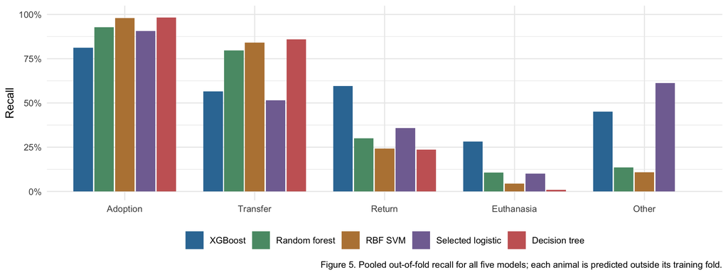

```r
ggplot(recall_long, aes(Class, Recall, fill = Model)) +
  geom_col(position = position_dodge(width = .8), width = .75) +
  scale_fill_manual(values = c("#3578A3", "#5A9975", "#B98342", "#8270A1", "#C96565")) +
  scale_y_continuous(limits = c(0, 1), labels = scales::percent) +
  labs(x = NULL, y = "Recall", fill = NULL,
       caption = "Figure 5. Pooled out-of-fold recall for all five models; each animal is predicted outside its training fold.") +
  theme(legend.position = "bottom")
```

**Show decision tree class-level evaluation**

```r
knitr::kable(dt_oof_pc, digits = 3, row.names = FALSE,
  col.names = c("Outcome", "Animals", "Precision", "Recall", "F1"),
  caption = "Table 5a. Selected decision tree: pooled out-of-fold performance by outcome.")
```

Table 5a. Selected decision tree: pooled out-of-fold performance by outcome.

| Outcome | Animals | Precision | Recall | F1 |
| --- | --- | --- | --- | --- |
| Adoption | 6676 | 0.852 | 0.983 | 0.913 |
| Transfer | 3897 | 0.773 | 0.859 | 0.813 |
| Return | 1144 | 0.533 | 0.236 | 0.327 |
| Euthanasia | 496 | 0.455 | 0.010 | 0.020 |
| Other | 333 | 0.000 | 0.000 | 0.000 |

Table 5a expands the decision-tree recall bars in Figure 5 to include precision, F1 and the number of animals in each outcome group. These pooled class scores use one validation prediction per training animal; the overall comparison in Table 5 uses the mean of the five fold scores.

**XGBoost has the highest mean CV macro-F1 among the five completed models.** XGBoost’s mean macro-F1 of 0.481 differs from random forest by +0.015; this small difference is not evidence of a decisive advantage. The practical distinction is its greater recall for Euthanasia and Other. Random forest and SVM achieve about 0.80 accuracy but identify few Euthanasia cases. The selected logistic model has lower macro-F1, although its stronger Return and Other recall makes it informative when missed cases are a priority. The single decision tree has mean macro-F1 0.414; its high accuracy coexists with weak recall for rare outcomes.

XGBoost’s lower accuracy (0.685) is a trade-off: improved attention to rare outcomes comes with more errors among common outcomes. Macro-F1 balances class precision and recall but does not encode a shelter’s actual error costs. Staff would need to determine those costs before adopting a model or decision threshold.

## 8. Final Results & Conclusion

### XGBoost held-out assessment

After CV selection, the chosen XGBoost configuration is refitted on all 12,546 training animals for the same 150 rounds and evaluated on the 3,134 test animals. Test labels do not determine parameters or the number of rounds in this procedure. Earlier project versions had already reported results on this split; this is a reproduced assessment, not a newly blinded test.

**Show R code**

```r
holdout_table <- data.frame(Model = c("XGBoost", "Majority class (baseline)"),
  `Macro-F1` = c(xgb_holdout$Macro_F1, majority_holdout$Macro_F1),
  `Balanced accuracy` = c(xgb_holdout$Balanced_Accuracy, majority_holdout$Balanced_Accuracy),
  Accuracy = c(xgb_holdout$Accuracy, majority_holdout$Accuracy), check.names = FALSE)
knitr::kable(holdout_table, digits = 3, caption = "Table 6. Assessment on the same held-out animals.")
```

Table 6. Assessment on the same held-out animals.

| Model | Macro-F1 | Balanced accuracy | Accuracy |
| --- | --- | --- | --- |
| XGBoost | 0.477 | 0.539 | 0.676 |
| Majority class (baseline) | 0.139 | 0.200 | 0.532 |

**Show R code**

```r
knitr::kable(xgb_test_pc, digits = 3, col.names = c("Outcome", "Animals", "Precision", "Recall", "F1"),
             caption = "Table 7. XGBoost: per-class held-out performance.")
```

Table 7. XGBoost: per-class held-out performance.

| Outcome | Animals | Precision | Recall | F1 |
| --- | --- | --- | --- | --- |
| Adoption | 1668 | 0.910 | 0.802 | 0.852 |
| Transfer | 974 | 0.886 | 0.557 | 0.684 |
| Return | 285 | 0.258 | 0.575 | 0.356 |
| Euthanasia | 124 | 0.176 | 0.315 | 0.225 |
| Other | 83 | 0.192 | 0.446 | 0.268 |

**Show R code**

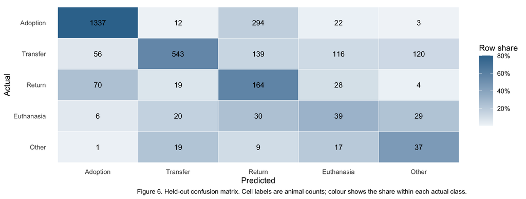

```r
test_predictions <- xgb_results$xgb_holdout_predictions
confusion <- as.data.frame(table(Actual = factor(test_predictions$Actual, levels = classes),
                                Predicted = factor(test_predictions$Predicted, levels = classes))) %>%
  group_by(Actual) %>% mutate(Share = Freq / sum(Freq))
ggplot(confusion, aes(Predicted, Actual, fill = Share)) +
  geom_tile(colour = "white") + geom_text(aes(label = Freq), size = 3.2) +
  scale_fill_gradient(low = "#f1f5f8", high = "#37749b", labels = scales::percent) +
  scale_y_discrete(limits = rev(classes)) +
  labs(fill = "Row share", caption = "Figure 6. Held-out confusion matrix. Cell labels are animal counts; colour shows the share within each actual class.") +
  theme(panel.grid = element_blank())
```

Held-out macro-F1 is **0.477**, compared with 0.481 in CV and 0.139 for the majority rule. Euthanasia recall is 31.5% and precision is 17.6%: many actual cases are missed, and many predictions of this outcome are false positives. The model therefore cannot determine an individual animal’s care or disposition.

### Interpretation and process reflection

Aggregating split gain over one-hot columns identifies **Spayed.Neutered** (35.2% of total gain) and **Age_Years_imputed** (32.8%) as the two largest contributors. Gain describes how the fitted trees split this dataset. Correlated predictors can share importance, and these values neither establish causation nor show that a field was available at intake.

**Show R code**

```r
predictor_names <- c(Spayed.Neutered = "Spayed/neutered", Age_Years_imputed = "Age at intake",
  Base_Color = "Base colour", primary.breed.group = "Primary breed", has_Name = "Name recorded",
  Sex = "Sex", Type = "Species", has_pattern = "Coat pattern")
importance_table <- data.frame(
  Predictor = unname(predictor_names[xgb_importance$Predictor[1:4]]),
  `Gain share` = pct(xgb_importance$Gain[1:4]),
  `Predictor ` = unname(predictor_names[xgb_importance$Predictor[5:8]]),
  `Gain share ` = pct(xgb_importance$Gain[5:8]), check.names = FALSE)
knitr::kable(importance_table, align = c("l", "r", "l", "r"),
  caption = "Table 8. XGBoost: share of split gain, aggregated across each predictor's encoded columns.")
```

Table 8. XGBoost: share of split gain, aggregated across each predictor’s encoded columns.

| Predictor | Gain share | Predictor | Gain share |
| --- | --- | --- | --- |
| Spayed/neutered | 35.2% | Name recorded | 5.3% |
| Age at intake | 32.8% | Sex | 5.0% |
| Base colour | 8.1% | Species | 3.4% |
| Primary breed | 7.9% | Coat pattern | 2.2% |

The Data Investigation Process connected the audit to implementation: repeated identifiers led to one record per animal, sparse breeds to training-based grouping, and imbalance to macro-F1 and per-class error analysis. Comparing unweighted, weighted and tuned models showed why a plausible adjustment does not necessarily improve the chosen metric. Shared folds allowed a consistent comparison; a stronger evaluation would fix the complete protocol before examining assessment results and reserve a later period for testing.

### Answer to the research question and limitations

Recorded animal characteristics provide useful but incomplete information about shelter outcomes. Among the five completed classifiers, **XGBoost** has the highest mean CV macro-F1. The tuned weighted XGBoost held-out macro-F1 is 0.477. The close CV scores of XGBoost and random forest, together with their different accuracy and recall profiles, make the choice dependent on the importance of recognising less common outcomes. The results support further evaluation as an aid to staff review, rather than automated outcome decisions.

The largest practical concern is prediction-time availability. In the logistic sensitivity analysis, excluding spay/neuter status reduces mean CV macro-F1 from 0.441 to 0.359; excluding both that field and name reduces it to 0.245. This dependence does not prove leakage, but it makes verification of intake-time values essential. The same sensitivity checks have not been established for XGBoost.

The Other category combines different outcomes, which makes it harder to interpret. The analysis covers each animal’s latest recorded admission at Austin Animal Center. The random test split assesses performance within this dataset; performance on future admissions remains untested. Before operational use at this shelter, future work should verify that predictors are available at admission and evaluate the model on a later cohort. Evaluation at other shelters would be needed only if broader use is intended.

## References

Chang, C.-C., & Lin, C.-J. (2011). LIBSVM: A library for support vector machines. *ACM Transactions on Intelligent Systems and Technology, 2*(3), Article 27. https://doi.org/10.1145/1961189.1961199

Chen, T., & Guestrin, C. (2016). XGBoost: A scalable tree boosting system. In *Proceedings of the 22nd ACM SIGKDD International Conference on Knowledge Discovery and Data Mining* (pp. 785–794). Association for Computing Machinery. https://doi.org/10.1145/2939672.2939785

City of Austin. (n.d.). *Austin Animal Center outcomes* [Data set]. City of Austin Open Data Portal. Retrieved September 20, 2026, from https://data.austintexas.gov/d/gsvs-ypi7

Hastie, T., Tibshirani, R., & Friedman, J. (2009). *The elements of statistical learning: Data mining, inference, and prediction* (2nd ed.). Springer. https://doi.org/10.1007/978-0-387-84858-7

## AI use statement

OpenAI Codex (GPT-5.6 and GPT-6, OpenAI, https://openai.com/codex/) assisted with R code review, data-processing checks, report organisation, wording and HTML formatting. The report contains AI-assisted text and code; the analysis and submission remain the group’s responsibility.

## Reproducibility

Keep the Rmd beside the raw CSV and install the packages listed in its setup block. Knit to HTML in RStudio; all five models are refitted. Command-line instructions are included in the HTML. For PDF, open the HTML in Chrome or Edge and choose Print → Save as PDF (A4).

**Show the single-file render command**

```r
rmarkdown::render("STAT5003_A2_W01G04.Rmd")
# Optional: use more SVM workers before rendering, if memory allows.
# options(stat5003.svm.workers = 3L)
```

**Show in-memory result verification**

```r
# Recompute evidence from the predictions produced above; this never refits a model.
validation_summary <- local({
  classes <- levels(shared$y_train)
  tolerance <- 1e-8
  checks <- list()
  record <- function(label, condition) {
    if (!isTRUE(condition)) stop("Validation failed: ", label, call. = FALSE)
    checks[[length(checks) + 1L]] <<- data.frame(Check = label, Passed = TRUE)
    invisible(TRUE)
  }
  close <- function(actual, expected, label) {
    actual <- as.numeric(actual); expected <- as.numeric(expected)
    record(label, length(actual) == length(expected) && length(actual) > 0L &&
             all(is.finite(actual)) && all(is.finite(expected)) &&
             all(abs(actual - expected) <= tolerance))
  }
  per_class <- function(actual, predicted) {
    stopifnot(length(actual) == length(predicted), !anyNA(actual), !anyNA(predicted),
              all(as.character(actual) %in% classes),
              all(as.character(predicted) %in% classes))
    cm <- table(factor(actual, levels = classes), factor(predicted, levels = classes))
    tp <- diag(cm); support <- rowSums(cm); predicted_n <- colSums(cm)
    data.frame(Class = classes, Support = as.numeric(support),
               Precision = ifelse(predicted_n > 0, tp / predicted_n, 0),
               Recall = ifelse(support > 0, tp / support, 0),
               F1 = ifelse(support + predicted_n > 0, 2 * tp / (support + predicted_n), 0),
               row.names = NULL)
  }
  metrics <- function(actual, predicted) {
    pc <- per_class(actual, predicted)
    c(Macro_F1 = mean(pc$F1), Balanced_Accuracy = mean(pc$Recall),
      Accuracy = mean(as.character(actual) == as.character(predicted)),
      Weighted_F1 = weighted.mean(pc$F1, pc$Support))
  }
  fold_metrics <- function(oof) {
    do.call(rbind, lapply(seq_along(shared$cv_folds), function(k) {
      z <- oof[oof$Fold == k, ]
      cbind(data.frame(Fold = k), as.data.frame(as.list(metrics(z$Actual, z$Predicted))))
    }))
  }
  check_pc <- function(computed, stored, label, support_name = "Support") {
    record(paste(label, "class labels"), nrow(stored) == length(classes) &&
             !anyDuplicated(stored$Class) && setequal(as.character(stored$Class), classes))
    stored <- stored[match(classes, stored$Class), ]
    for (column in c("Support", "Precision", "Recall", "F1")) {
      expected_column <- if (column == "Support") support_name else column
      close(computed[[column]], stored[[expected_column]], paste(label, column))
    }
  }
  check_folds <- function(computed, stored, label,
                          columns = c(Macro_F1 = "Macro_F1",
                                      Balanced_Accuracy = "Balanced_Accuracy",
                                      Accuracy = "Accuracy")) {
    stored <- stored[order(stored$Fold), ]
    record(paste(label, "five fold IDs"),
           identical(as.integer(stored$Fold), seq_along(shared$cv_folds)))
    for (column in names(columns))
      close(computed[[column]], stored[[columns[[column]]]], paste(label, column))
  }
  check_summary <- function(folds, stored, label,
                            columns = c(Macro_F1 = "Mean_CV_Macro_F1",
                                        Balanced_Accuracy = "Mean_CV_Balanced_Accuracy",
                                        Accuracy = "Mean_CV_Accuracy"),
                            sd_column = "SD_CV_Macro_F1") {
    record(paste(label, "one summary row"), nrow(stored) == 1L)
    for (column in names(columns))
      close(mean(folds[[column]]), stored[[columns[[column]]]], paste(label, column))
    close(sd(folds$Macro_F1), stored[[sd_column]], paste(label, "macro-F1 SD"))
  }
  check_grid <- function(folds, summary, keys, label,
                         columns = c(Macro_F1 = "Mean_CV_Macro_F1",
                                     Balanced_Accuracy = "Mean_CV_Balanced_Accuracy",
                                     Accuracy = "Mean_CV_Accuracy"),
                         sd_column = "SD_CV_Macro_F1") {
    record(paste(label, "grid size"), nrow(folds) == 5L * nrow(summary))
    for (i in seq_len(nrow(summary))) {
      use <- rep(TRUE, nrow(folds))
      for (key in keys) use <- use & folds[[key]] == summary[[key]][i]
      z <- folds[use, ]
      record(paste(label, "candidate", i, "fold coverage"),
             identical(sort(as.integer(z$Fold)), 1:5))
      for (column in names(columns))
        close(mean(z[[column]]), summary[[columns[[column]]]][i],
              paste(label, "candidate", i, column))
      close(sd(z$Macro_F1), summary[[sd_column]][i],
            paste(label, "candidate", i, "macro-F1 SD"))
    }
  }

  # Every animal belongs to one partition, and every training row to one CV fold.
  record("Training/test animal IDs are disjoint",
         length(intersect(shared$train_raw$Animal.ID, shared$test_raw$Animal.ID)) == 0L)
  record("Training/test animal IDs are unique",
         !anyDuplicated(shared$train_raw$Animal.ID) && !anyDuplicated(shared$test_raw$Animal.ID))
  record("CV covers every training row exactly once",
         identical(sort(as.integer(unlist(shared$cv_folds))), seq_along(shared$y_train)))
  fold_id <- integer(length(shared$y_train))
  for (k in seq_along(shared$cv_folds)) {
    fold_id[shared$cv_folds[[k]]] <- k
    record(paste("Shared validation labels, fold", k),
           identical(as.character(shared$cv_data[[k]]$y_valid),
                     as.character(shared$y_train[shared$cv_folds[[k]]])))
  }
  normalise_oof <- function(x, row, truth, predicted) {
    data.frame(Training_Row = x[[ row]], Fold = x$Fold,
               Actual = as.character(x[[truth]]), Predicted = as.character(x[[predicted]]))
  }
  oof <- list(
    Logistic = normalise_oof(lr_results$cv_oof_predictions, "train_row", "truth", "pred"),
    Random_forest = rf_results$rf_selected_oof_predictions,
    SVM = normalise_oof(svm_results$selected_oof_predictions, "Row", "Actual", "Predicted"),
    XGBoost = xgb_results$xgb_selected_oof_predictions,
    Decision_tree = dt_results$decision_tree_selected_oof_predictions
  )
  recomputed_folds <- recomputed_pc <- list()
  for (name in names(oof)) {
    x <- oof[[name]][order(oof[[name]]$Training_Row), ]
    record(paste(name, "OOF training-row order"),
           identical(as.integer(x$Training_Row), seq_along(shared$y_train)))
    record(paste(name, "OOF labels and folds"),
           identical(as.character(x$Actual), as.character(shared$y_train)) &&
             identical(as.integer(x$Fold), fold_id))
    record(paste(name, "OOF valid predictions"), !anyNA(x$Predicted) &&
             all(as.character(x$Predicted) %in% classes))
    oof[[name]] <- x
    recomputed_folds[[name]] <- fold_metrics(x)
    recomputed_pc[[name]] <- per_class(x$Actual, x$Predicted)
  }
  record("Logistic OOF animal IDs", identical(
    as.character(lr_results$cv_oof_predictions$Animal.ID[
      order(lr_results$cv_oof_predictions$train_row)]),
    as.character(shared$train_raw$Animal.ID)))
```

```r
  # LR uses lower-case names and retains both ordinary and regularised model families.
  lr_name <- lr_results$selected$name
  lr_stored <- lr_results$cv_fold_metrics[lr_results$cv_fold_metrics$Model == lr_name, ]
  lr_columns <- c(Macro_F1 = "macro_F1", Balanced_Accuracy = "balanced_accuracy", Accuracy = "accuracy")
  check_folds(recomputed_folds$Logistic, lr_stored, "Logistic selected CV", lr_columns)
  check_summary(recomputed_folds$Logistic,
                lr_results$cv_model_comparison[lr_results$cv_model_comparison$Model == lr_name, ],
                "Logistic selected summary", lr_columns, "macro_F1_sd")
  lr_candidates <- lr_results$cv_model_comparison[
    lr_results$cv_model_comparison$Model != "Majority class", ]
  close(lr_candidates$macro_F1[lr_candidates$Model == lr_name],
        max(lr_candidates$macro_F1), "Logistic family selection maximises mean CV macro-F1")
  for (model in unique(lr_results$cv_fold_metrics$Model)) {
    z <- lr_results$cv_fold_metrics[lr_results$cv_fold_metrics$Model == model, ]
    z$Macro_F1 <- z$macro_F1; z$Balanced_Accuracy <- z$balanced_accuracy; z$Accuracy <- z$accuracy
    check_summary(z, lr_results$cv_model_comparison[lr_results$cv_model_comparison$Model == model, ],
                  paste("Logistic", model), lr_columns, "macro_F1_sd")
  }
  for (spec in unique(lr_results$glmnet_tuning_grid$spec)) {
    grid <- lr_results$glmnet_tuning_grid[lr_results$glmnet_tuning_grid$spec == spec, ]
    best <- grid[which.max(grid$mean_macro_F1), ]
    eligible <- grid[grid$alpha == best$alpha &
                       grid$mean_macro_F1 >= best$mean_macro_F1 - best$se_macro_F1, ]
    chosen <- eligible[which.max(eligible$lambda), ]
    stored <- lr_results$tuned_hyperparameters[
      lr_results$tuned_hyperparameters$spec == spec &
        lr_results$tuned_hyperparameters$rule == "1-SE (used)", ]
    close(stored$alpha, chosen$alpha, paste("Logistic", spec, "1-SE alpha"))
    close(stored$lambda, chosen$lambda, paste("Logistic", spec, "1-SE lambda"))
  }

  rf_selected <- rf_results$rf_selected_metrics
  rf_folds <- rf_results$rf_cv_fold_scores[
    rf_results$rf_cv_fold_scores$num.trees == rf_selected$num.trees &
      rf_results$rf_cv_fold_scores$mtry == rf_selected$mtry, ]
  check_folds(recomputed_folds$Random_forest, rf_folds, "Random forest selected CV")
  check_pc(recomputed_pc$Random_forest, rf_results$rf_oof_per_class, "Random forest pooled OOF")
  rf_summary_columns <- c(Macro_F1 = "Mean_Macro_F1", Balanced_Accuracy = "Mean_Balanced_Accuracy",
                          Accuracy = "Mean_Accuracy")
  check_grid(rf_results$rf_cv_fold_scores, rf_results$rf_cv_summary,
             c("num.trees", "mtry"), "Random forest", rf_summary_columns, "SD_Macro_F1")
  close(rf_selected$Mean_CV_Macro_F1, max(rf_results$rf_cv_summary$Mean_Macro_F1),
        "Random forest selected grid maximum")
  close(metrics(oof$Random_forest$Actual, oof$Random_forest$Predicted)[1:3],
        unlist(rf_selected[c("Macro_F1_pooled_oof", "Balanced_Accuracy_pooled_oof",
                             "Accuracy_pooled_oof")]), "Random forest pooled summary")

  svm_selected <- svm_results$baseline_vs_selected[
    svm_results$baseline_vs_selected$Model == "SVM selected by CV", ]
  svm_folds <- svm_results$cv_fold_scores[svm_results$cv_fold_scores$Candidate == svm_selected$Candidate, ]
  check_folds(recomputed_folds$SVM, svm_folds, "SVM selected CV")
  check_pc(recomputed_pc$SVM, svm_results$oof_per_class, "SVM pooled OOF")
  check_summary(recomputed_folds$SVM, svm_selected, "SVM selected summary",
                rf_summary_columns, "SD_Macro_F1")
  check_grid(svm_results$cv_fold_scores, svm_results$tuning_summary, "Candidate", "SVM",
             rf_summary_columns, "SD_Macro_F1")
  close(svm_selected$Mean_Macro_F1, max(svm_results$tuning_summary$Mean_Macro_F1),
        "SVM selected grid maximum")
  close(metrics(oof$SVM$Actual, oof$SVM$Predicted)[1:3],
        unlist(svm_results$oof_pooled_metrics[c("Macro_F1", "Balanced_Accuracy", "Accuracy")]),
        "SVM pooled summary")

  four_columns <- c(Macro_F1 = "Macro_F1", Balanced_Accuracy = "Balanced_Accuracy",
                     Accuracy = "Accuracy", Weighted_F1 = "Weighted_F1")
  mean_four <- paste0("Mean_CV_", four_columns)
  names(mean_four) <- names(four_columns)
  for (name in c("XGBoost", "Decision_tree")) {
    result <- if (name == "XGBoost") xgb_results else dt_results
    prefix <- if (name == "XGBoost") "xgb" else "decision_tree"
    check_folds(recomputed_folds[[name]], result[[paste0(prefix, "_selected_oof_fold_scores")]],
                paste(name, "selected CV"), four_columns)
    check_pc(recomputed_pc[[name]], result[[paste0(prefix, "_oof_per_class")]],
             paste(name, "pooled OOF"))
    check_summary(recomputed_folds[[name]], result[[paste0(prefix, "_selected_metrics")]],
                  paste(name, "selected summary"), mean_four)
    check_grid(result[[paste0(prefix, "_grid_fold_scores")]], result[[paste0(prefix, "_grid_summary")]],
               "Grid_ID", name, mean_four)
    close(result[[paste0(prefix, "_selected_metrics")]]$Mean_CV_Macro_F1,
          max(result[[paste0(prefix, "_grid_summary")]]$Mean_CV_Macro_F1),
          paste(name, "selected grid maximum"))
  }
  baseline_oof <- dt_results$decision_tree_baseline_oof_predictions
  baseline_oof <- baseline_oof[order(baseline_oof$Training_Row), ]
  record("Decision tree baseline OOF alignment",
         identical(as.integer(baseline_oof$Training_Row), seq_along(shared$y_train)) &&
           identical(as.character(baseline_oof$Actual), as.character(shared$y_train)) &&
           identical(as.integer(baseline_oof$Fold), fold_id))
  baseline_folds <- fold_metrics(baseline_oof)
  check_folds(baseline_folds, dt_results$decision_tree_baseline_fold_scores,
              "Decision tree baseline CV")
  check_summary(baseline_folds, dt_results$decision_tree_baseline_metrics,
                "Decision tree baseline summary")
  dt_grid <- dt_results$decision_tree_grid_summary
  dt_best <- dt_grid[order(-dt_grid$Mean_CV_Macro_F1, -dt_grid$Mean_CV_Balanced_Accuracy,
                           dt_grid$maxdepth, -dt_grid$cp, dt_grid$minsplit), ][1, ]
  close(dt_results$decision_tree_selected_config$Grid_ID, dt_best$Grid_ID,
        "Decision tree deterministic tie-breaking")
  dt_pooled <- dt_results$decision_tree_oof_metrics
  close(metrics(oof$Decision_tree$Actual, oof$Decision_tree$Predicted),
        dt_pooled$Value[match(names(four_columns), dt_pooled$Metric)],
        "Decision tree pooled summary")
  close(metrics(oof$XGBoost$Actual, oof$XGBoost$Predicted),
        unlist(xgb_results$xgb_selected_metrics[names(four_columns)]), "XGBoost pooled summary")
```

```r
  # Held-out predictions are checked separately and never affect selection.
  check_holdout <- function(predictions, label) {
    predictions <- predictions[order(predictions$Test_Row), ]
    record(paste(label, "holdout rows and labels"),
           identical(as.integer(predictions$Test_Row), seq_along(shared$y_test)) &&
             identical(as.character(predictions$Actual), as.character(shared$y_test)))
    metrics(predictions$Actual, predictions$Predicted)
  }
  lr_test <- lr_results$test_predictions
  record("Logistic holdout animal IDs", identical(as.character(lr_test$Animal.ID),
                                                 as.character(shared$test_raw$Animal.ID)))
  lr_holdout <- data.frame(Test_Row = seq_len(nrow(lr_test)), Actual = as.character(lr_test$truth),
                           Predicted = as.character(lr_test$pred))
  lr_test_metric <- check_holdout(lr_holdout, "Logistic")
  lr_test_stored <- lr_results$metrics_summary[grepl("Held-out", lr_results$metrics_summary$Evaluation), ]
  close(lr_test_metric[1:3], unlist(lr_test_stored[unname(lr_columns)]), "Logistic holdout summary")
  check_pc(per_class(lr_holdout$Actual, lr_holdout$Predicted), lr_results$test_per_class,
           "Logistic holdout per class", "n_test")
  for (name in c("XGBoost", "Decision_tree")) {
    result <- if (name == "XGBoost") xgb_results else dt_results
    prefix <- if (name == "XGBoost") "xgb" else "decision_tree"
    predictions <- result[[paste0(prefix, "_holdout_predictions")]]
    m <- check_holdout(predictions, name)
    stored <- result[[paste0(prefix, "_holdout_metrics")]]
    expected <- if (name == "XGBoost") unlist(stored[names(four_columns)]) else
      stored$Value[match(names(four_columns), stored$Metric)]
    close(m, expected, paste(name, "holdout summary"))
    check_pc(per_class(predictions$Actual, predictions$Predicted),
             result[[paste0(prefix, "_holdout_per_class")]], paste(name, "holdout per class"))
  }
  rf_test <- rf_results$rf_baseline_holdout_predictions
  rf_test_metric <- check_holdout(rf_test, "Random forest baseline")
  close(rf_test_metric[1:3], unlist(rf_results$rf_baseline_holdout_metrics[
    c("Macro_F1", "Balanced_Accuracy", "Accuracy")]), "Random forest baseline holdout summary")

  # Majority-class evidence is recomputed directly from training labels.
  majority_prediction <- rep(NA_character_, length(shared$y_train))
  for (k in seq_along(shared$cv_folds))
    majority_prediction[shared$cv_folds[[k]]] <- names(which.max(table(shared$cv_data[[k]]$y_train)))
  majority_oof <- data.frame(Actual = as.character(shared$y_train),
                             Predicted = majority_prediction, Fold = fold_id)
  majority_folds <- fold_metrics(majority_oof)
  check_folds(majority_folds, xgb_results$majority_cv_fold_scores, "Majority CV", four_columns)
  check_summary(majority_folds, xgb_results$majority_cv_summary, "Majority CV summary", mean_four)
  check_pc(per_class(majority_oof$Actual, majority_oof$Predicted),
           xgb_results$majority_oof_per_class, "Majority pooled OOF")
  majority <- names(which.max(table(shared$y_train)))
  close(metrics(shared$y_test, rep(majority, length(shared$y_test))),
        unlist(xgb_results$majority_holdout_metrics[names(four_columns)]), "Majority holdout")
  close(metrics(shared$y_train, rep(majority, length(shared$y_train))),
        unlist(xgb_results$majority_training_metrics[names(four_columns)]), "Majority training")

  do.call(rbind, checks)
})
```

**Show report-table assembly**

```r
# Assemble the report directly from the models fitted above.
lr_cv <- lr_results$cv_model_comparison
rf_cv <- rf_results$rf_cv_summary
svm_cv <- svm_results$baseline_vs_selected
xgb_cv <- xgb_results$xgb_configuration_summary
xgb_selected <- xgb_results$xgb_selected_metrics
xgb_holdout <- xgb_results$xgb_holdout_metrics
xgb_test_pc <- xgb_results$xgb_holdout_per_class
xgb_importance <- xgb_results$xgb_feature_importance
dt_cv <- dt_results$decision_tree_selected_metrics
dt_base <- dt_results$decision_tree_baseline_metrics
dt_oof_pc <- dt_results$decision_tree_oof_per_class
dt_holdout <- dt_results$decision_tree_holdout_metrics
dt_test_pc <- dt_results$decision_tree_holdout_per_class
dt_importance <- dt_results$decision_tree_feature_importance
majority_cv <- xgb_results$majority_cv_summary
majority_holdout <- xgb_results$majority_holdout_metrics
majority_training <- xgb_results$majority_training_metrics
lr_selected <- lr_cv[lr_cv$Model == lr_results$selected$name, ]
lr_m3 <- lr_cv[grepl("^M3 ", lr_cv$Model), ]
lr_base <- lr_cv[grepl("^M0 ", lr_cv$Model), ]
rf_selected <- rf_cv[which.max(rf_cv$Mean_Macro_F1), ]
rf_base <- rf_cv[rf_cv$num.trees == 500 & rf_cv$mtry == 2, ]
svm_selected <- svm_cv[svm_cv$Model == "SVM selected by CV", ]
svm_base <- svm_cv[svm_cv$Model == "SVM baseline", ]
comparison <- data.frame(
  Model = c(
    "XGBoost",
    "Random forest",
    "RBF SVM",
    paste0("Multinomial logistic (", sub(" .*", "", lr_results$selected$name), ")"),
    "Decision tree",
    "Majority class (baseline)"
  ),
  Macro_F1 = c(
    xgb_selected$Mean_CV_Macro_F1,
    rf_selected$Mean_Macro_F1,
    svm_selected$Mean_Macro_F1,
    lr_selected$macro_F1,
    dt_cv$Mean_CV_Macro_F1,
    majority_cv$Mean_CV_Macro_F1
  ),
  SD = c(
    xgb_selected$SD_CV_Macro_F1,
    rf_selected$SD_Macro_F1,
    svm_selected$SD_Macro_F1,
    lr_selected$macro_F1_sd,
    dt_cv$SD_CV_Macro_F1,
    majority_cv$SD_CV_Macro_F1
  ),
  Balanced_Accuracy = c(
    xgb_selected$Mean_CV_Balanced_Accuracy,
    rf_selected$Mean_Balanced_Accuracy,
    svm_selected$Mean_Balanced_Accuracy,
    lr_selected$balanced_accuracy,
    dt_cv$Mean_CV_Balanced_Accuracy,
    majority_cv$Mean_CV_Balanced_Accuracy
  ),
  Accuracy = c(
    xgb_selected$Mean_CV_Accuracy,
    rf_selected$Mean_Accuracy,
    svm_selected$Mean_Accuracy,
    lr_selected$accuracy,
    dt_cv$Mean_CV_Accuracy,
    majority_cv$Mean_CV_Accuracy
  )
)
comparison <- comparison[order(-comparison$Macro_F1), ]
rownames(comparison) <- NULL
selected_model_name <- comparison$Model[which.max(comparison$Macro_F1)]
lr_oof <- lr_results$cv_oof_predictions
classes <- levels(y_train)
pc_metrics <- function(actual, pred) {
  cm <- table(factor(actual, levels = classes), factor(pred, levels = classes))
  support <- rowSums(cm); predicted <- colSums(cm); tp <- diag(cm)
  data.frame(Class = classes, Support = as.integer(support),
             Precision = ifelse(predicted > 0, tp / predicted, 0),
             Recall = tp / support, F1 = 2 * tp / (support + predicted))
}
pc_sources <- list(
  XGBoost = xgb_results$xgb_oof_per_class,
  `Random forest` = rf_results$rf_oof_per_class,
  `RBF SVM` = svm_results$oof_per_class,
  `Selected logistic` = pc_metrics(lr_oof$truth, lr_oof$pred),
  `Decision tree` = dt_results$decision_tree_oof_per_class
)
recall_long <- bind_rows(lapply(names(pc_sources), function(model) {
  transform(pc_sources[[model]], Model = model)
}))
recall_long$Class <- factor(recall_long$Class, levels = classes)
recall_long$Model <- factor(recall_long$Model, levels = names(pc_sources))
fmt <- function(x, digits = 3) sprintf(paste0("%.", digits, "f"), x)
pct <- function(x, digits = 1) paste0(fmt(100 * x, digits), "%")
comma <- function(x) format(x, big.mark = ",", scientific = FALSE, trim = TRUE)
quality_value <- function(field) quality_summary$Missing_pct[quality_summary$Feature == field]
age_by_outcome <- data.frame(Outcome = data_selected$Outcome.Group, Age = age_audit$Age_Years_raw) %>%
  filter(is.finite(Age), Age >= 0) %>% group_by(Outcome) %>%
  summarise(Median = median(Age), .groups = "drop")
lr_sensitivity <- lr_results$sensitivity_checks

eda_rate <- function(summary, level, outcome) {
  pct(summary$Prop[summary$Level == level & summary$Outcome.Group == outcome])
}
theme_set(theme_minimal(base_size = 10))
palette_outcome <- eda$outcome_colours
```

**Show R and package versions**